# The Little Learner.Friedman2023

[figure not shown]

The Little Learner

The Little Learner

A Straight Line to Deep Learning

Daniel P. Friedman

Anurag Mendhekar

Drawings by Qingqing Su

Forewords by Guy L. Steele Jr. and Peter Norvig

The MIT Press

Cambridge, Massachusetts

London, England

© 2023 Daniel P. Friedman and Anurag Mendhekar

All rights reserved. With the exception of completed code examples in solid boxes, no part of this book may be reproduced in any form by any electronic or mechanical means (including photocopying, recording, or information storage and retrieval) without permission in writing from the publisher. The completed code examples that are presented in solid boxes are licensed under a Creative Commons Attribution 4.0 International License (CC-By 4.0).

This book was set in Computer Modern Unicode by the authors using .

Library of Congress Cataloging-in-Publication Data is available.

ISBN 978-0-262-54637-9

10 9 8 7 6 5 4 3 2 1

d_r0

> *To Mary, from the title of the song this is “Dedicated to the One I Love.”*

> *What a fabulous ride you have taken me on!*

> *With all my love and admiration.*

> *–Danny*

> *To the shining stars in my life, Aruna, Rishma, and Aria Nina, and my constant 4-legged companions Chikki and Heera.*

> *Without you there would only be darkness.*

> *–Anurag*

We ran into each other on Friday, the 13th of April, 2018, at the over-crowded, official opening of the Luddy School of Informatics, Computing, and Engineering and we decided to write a book on machine learning based on this *very* deep conversation directly following the close of the event.

*Anurag*: I want to write a little book with you.

*Dan*: Let's do it!

⋮

*a few seconds later*

⋮

*Dan*: What's the topic?

*Anurag*: Machine learning

*Dan*: Now, that will be a worthy challenge!

And the rest of the time we reminisced …

# Contents

Foreword by Guy L. Steele Jr.

Foreword by Peter Norvig

Preface

Transcribing to Scheme

0: Are You Schemish?

1: The Lines Sleep Tonight

2: The More We Learn, the Tenser We Become

Interlude I: The More We Extend, the Less Tensor We Get

3: Running Down a Slippery Slope

4: Slip-slidin’ Away

Interlude II: Too Many Toys Make Us Hyperactive

5: Target Practice

Interlude III: The Shape of Things to Come

6: An Apple a Day

7: The Crazy “ates”

8: The Nearer Your Destination, the Slower You Become

Interlude IV: Smooth Operator

9: Be Adamant

Interlude V: Extensio Magnifico!

10: Doing the Neuron Dance

11: In Love with the Shape of Relu

12: Rock Around the Block

13: An Eye for an Iris

Interlude VI: How the Model Trains

Interlude VII: Are Your Signals Crossed?

14: It's Really Not That Convoluted

15: …But It Is Correlated!

Epilogue - We've Only Just Begun

Appendix A: Ghost in the Machine

Appendix B: I Could Have Raced All Day

Acknowledgments

References

Index

# Foreword

by Guy L. Steele Jr.

This book is *exactly* right.

Dan Friedman, with his able and expert co-authors, has been writing books in his unique “Little” style for over four decades. Every one is a gem, explaining deep and important ideas in computer science in bite-sized chunks. Dan and his co-authors have raised the “programmed learning” question-and-answer format to an art form, to a conversational style that seems almost breezy. This very volume introduces two innovations, *nuggets* and *revision charts*, that further streamline the presentation of chunks of program code and their behavior.

Regarding the fundamental ideas behind machine learning

> This book presents *exactly the right ideas*

> in *exactly the right format*

> and

> in *exactly the right order*

> All you need to do is read the book *in order* (don't skip ahead!)

The authors themselves remark:

> “Little” books are all about packaging ideas neatly into little boxes.

What ideas are in this book? The mathematics and computational techniques of machine learning, of course: you'll learn about successive approximation, stochastic gradient descent, neural networks, and automatic back-propagation. However, as a programming languages guy, I am also interested in how the authors use language to frame the mathematics. To me, a big overarching idea here is how the authors use *higher-order functions*—that is, functions that take other functions as arguments and/or return other functions as results—to explain the data structures and computations of machine learning.

The fundamental data structure is the *tensor*, which at first glance looks like an ordinary array or matrix; but the authors explain that tensor operations have the additional property of automatically using a higher-order mapping function when appropriate, and this—almost magically, it seems to me—enables a function apparently written for scalars (single numbers), or a tensor of a specific dimension, to be applied generally to all kinds and sizes of arrays, vectors, and matrices with no additional effort.

Another application of higher-order functions is *currying*, which allows you to give a function some of its arguments now and others later—when you give it some of its arguments now, it returns another function that can be applied to the other arguments later to get the final answer. The presentation in this book uses currying in a clear—and, to me, pleasantly surprising—way to explain the difference between *arguments* and *parameters* in machine learning, and why they need to be presented in a specific order, some now and some later. (A third sort of argument, *hyperparameters*, is also explained using yet another programming-language mechanism. If you're familiar with the buzzphrase “dynamic scoping” you are in for a treat; if you are not, no worries—hyperparameters and their behavior are clearly explained by example.)

The third use of higher-order functions in this book is to structure the *composition* of large neural networks from smaller building blocks, and to explain the behavior and training of these networks.

A fourth use of higher-order functions is to provide for *data abstraction*. At first, parameters are always simple numbers, but the code for processing them is so deftly defined using just a few interface functions—exactly the right ones—that the higher-order code does not need to be changed when the representation of parameters is extended. (A key idea is *projection*: provide two functions, one that projects data into an alternate representation that is easier to compute on, and another that pulls a computed result back into the original representation. Then a function that accepts two such functions as arguments can be used in a very general way.) Similarly, scalars are simple numbers throughout most of the book, but when it becomes necessary to generalize them to *duals* in appendix A, higher-order functions make the task simple.

> So if you are interested in big-picture programming-language ideas

> Keep these applications of higher-order functions in mind as you read

> You may enjoy spotting them as they go by

> but if you don't care about higher-order functions

> Please ignore everything I have just said

> Immerse yourself in the story of machine learning

> This book needs no introduction; it is exactly right for its purpose.

I have read all the books in the “Little” series; each time I have said to myself, “This is the best one ever!” This time, Dan and Anurag have done it again—this is the best. It stands on its own; you don't need to have read earlier “Little” books to understand this one, and you don't need to understand Scheme or any other programming language ahead of time. The dozen or so programming-language ideas you need are explained along the way, each exactly when you need it, and with plenty of examples. Give it time and enjoy the journey.

Guy L. Steele Jr.  
Lexington, Massachusetts  
August 2022

# Foreword

by Peter Norvig

| Hi, I'm Peter Norvig, a long-time researcher and practitioner of machine learning. I've had the pleasure of reading this book, and was asked to make some comments on it. I'm going to do that in the fo… | <sup>1</sup> | Thanks, I'm happy to be here, even if I am imaginary. And please, call me Tipi. |
| --- | --- | --- |
| Okay, Tipi. I can say that I thoroughly enjoyed the book and appreciated the way it carefully developed the key concepts. How did you find the book? | <sup>2</sup> | To be honest, I haven't read it all yet. So far I've only skimmed it. It looks interesting, but I'm trying to decide if it is worth the time and effort to work through the whole book. |
| You have a good point. This book is more interactive than most, and asks more of the reader. I can't tell you whether the book is right for you, but I can say that the best way to achieve expertise in… | <sup>3</sup> | It does seem to demand more effort than a typical book, because you have to work through the examples. |
| Working through the examples really helps the material stick with you! I remember one time I was discussing a machine learning technique with a colleague, and they said they didn't see how a particula… | <sup>4</sup> | Okay, you convinced me that practice makes improvement. When I look around, however, I see machine learning tools mainly in Python, or maybe Java or R, but not so much in Scheme. |
| This book isn't about programming languages, and it isn't about machine learning toolkits. It is about explaining the fundamental concepts of machine learning, and implementing them in the simplest po… | <sup>5</sup> | Is Scheme a good choice for that? |
| I think it is. It is one of the simplest possible programming languages. Working with it is like sticking with basic mathematical notation, but it happens to be executable code, so there's no ambiguit… | <sup>6</sup> | But will this book have me practicing the right things? |
| After you finish this book, are you going to take the Scheme code and run it in your next machine learning project? Maybe, maybe not. But even if you use a machine learning toolkit like TensorFlow or … | <sup>7</sup> | Okay, I'm all for understanding the fundamentals. But is this book all theoretical? All mathy? I want a good understanding of the fundamentals, but I want that understanding to be useful in practice. |
| This book will give you that. It takes you through the key ideas of machine learning. It is definitely not “mathy’’; it has the minimum amount of math notation, and most topics are described with code… | <sup>8</sup> | That sounds good. What are some of the key topics I will learn about? And how long does it take to get to them? |
| I think the topics are presented at just the right pace. It starts off introducing the absolute basics of Scheme and of lines and linear equations. By page 63 we get to L2 loss, learning rate, and gra… | <sup>9</sup> | Okay, you've convinced me; skimming wasn't enough, I'm going to work through the whole book. By the way, was there anything in the book you disagree with? |
| I whole-heartedly agree with the pedagogical style of working through an issue, seeing the finished results that you have accomplished, and then enjoying a break. I've used the Pomodoro Technique to h… | <sup>10</sup> | As a typical reader, I consume 77 grams of sugar per day. I'll heed your warning and try to get closer to the daily recommended level of 24 grams per day. |

Peter Norvig  
Palo Alto, California  
August 2022

# Preface

> You can't skip chapters, that's not how life works. You have to read every line, meet every character. You won't enjoy all of it. Hell, some chapters will make you cry for weeks. You will read things you don't want to read, you will have moments when you don't want the pages to end. But you have to keep going. Stories keep the world revolving. Live yours, don't miss out.

> – Courtney Peppernell, a poem from *Pillow Thoughts II,* published by Andrews McMeel Publishing, © 2018.

Deep learning, an emerging area of artificial intelligence, has revolutionized the way problems are solved, be it winning at Go, recognizing cats in pictures, or asking a smart speaker to order pizza. The most beautiful thing about deep learning is how simple pieces come together to solve large, complex problems. How can we understand what makes these deep learning tools work? Our approach is to build them, a little bit at a time, and watch them work.

The ability to grapple with noisy data is what makes deep learning, which is a type of machine learning, tantalizing. Consequently, being 100% correct is no longer attainable. Our sense of exactness of solutions, which is common to many problems for which we write programs, disappears. While much of this lies with the problem domain itself, we can, and should, maintain a sense of exactness in the functions we define—to keep true to our intuition so we can be assured that these functions meet our expectations.

To learn these tools, we require only basic high-school mathematics along with some programming experience. The functions we define are intended to be run and experimented with. It is, of course, possible to read this book without running them, but each definition must be carefully understood.

## How to read this book

Because you may find that either this topic or our exposition method is new, you should read each chapter until you fully understand it. This might lead to reading some chapters more than once. Do not move forward until the chapter being read is completely clear. Be determined. Work with others and discuss with them what has been unclear until each little piece falls into place.

It is futile to read ahead in a “Little” book because everything is structured in *exactly* the right order as a sequence of numbered *frames* separated by horizontal lines. Each chapter is fairly short and has lots of *white space,* so rereading an entire chapter carefully to regain a lost thread is not unreasonable.

We also have two appendices in *exactly* the right order. They explain how to build the underlying tools that help us with deep learning. These appendices also assume very little by way of the background knowledge necessary, but are a wee bit more demanding of the reader than the rest of the book.

## How our programs are written

We package our ideas as little Scheme programs. Scheme allows our thoughts to be expressed clearly and directly, and with minimal fuss. It is a language that assumes very little and gets out of the way quickly, so that the code speaks for itself.

We use a very small subset of Scheme: **define** (or **let**) allows a global (or local) name to be given to a value, **lambda** creates a function as a value, and **cond** dispatches over a sequence of (*test value*) pairs. There are also primitive functions such as +,−, and * that operate over numbers. This is explained in *Are you Schemish?*.

We use *little boxes* to hold the code and we explain how the programs in these boxes work. Once *Are you Schemish?* is understood, each subsequent frame, when read in order, is easily digestable. This book builds up a collection of concepts, with nearly all of them being functions. If we request a function definition (in the left part of a frame), take some time and produce a plausible one before looking at our answer (in the right part of the frame). Here is a simple example of a frame with little boxes:

| This is a little box (**define** *a-function* *… that fits nicely in a little box …*) | <sup>1</sup> | This is a red box They don't get wider than this The first memorable one is frame 26:25 and that means frame 25 on page 26 (**define** *another-function* • *… remember this one! …*) |
| --- | --- | --- |

We also categorize key properties as either *rules* or *laws*. Our rules are about the structure of entities, like their sizes. Our laws, on the other hand, are about the behavior of entities, like their equalities and invariants.

## How to run the code

We have collected the functions and syntactic extensions necessary for the code in this book into a MAchine Learning Toolkit package, called *Malt*. Malt is a package in Racket, which is a superset of our small subset of Scheme. The package includes our code and examples as well as the tools necessary to experiment with them. Advice for its use is available at *www.thelittlelearner.com*.

## How to eat desserts

Those familiar with “Little” books may miss the funny Scheme symbols that have been an opportunity to inject humor into the data. It is very difficult to find humor in numbers, though occasionally we find some elsewhere. So, we have included a cornucopia of desserts for consumption at a nearby outdoor café. Don't skip them! But don't overdo them either, and remember to eat your “peas and carrots” first.

We hope this little foray into deep learning will be fun for you, and we hope that it's as interesting to read as we have found it to write.

*Bon appétit!*

Daniel P. Friedman  
Bloomington, Indiana

Anurag Mendhekar  
Los Altos, California

# Transcribing to Scheme

We write some of our functions using a more compact notation so that they are easier to read and to fit snugly in the little boxes. Before running a program, be sure to transcribe our notation into Scheme code. The table below shows how to write these directly in Scheme.

The *first* column in the table below refers to the earliest occurrence in the book of the notation shown in the *second* column. The *third* column shows how to transcribe our programs, (e.g. [ 5 (+ 10 2) 28 ] is transcribed as (**tensor 5 (+ 10 2) 28)**).

| Page:Frame | Notation | Transcription |
| --- | --- | --- |
| 24:17 | [ *t ts …*] | (**tensor** *t ts …*) |
| 26:24 | *l<sub>i</sub>* | (**ref** *l i*) |
| 27:27 | (**list** *m …*) | (**list** *m …*) |
| 33:17 |  | (**tlen** *t*) |
| 36:24 | *t\|<sub>i</sub>* | (**tref** *t i*) |
| 41:42 | *\|l\|* | (**len** *l*) |
| 52:22 | (⟨*op*⟩⟨*ran*k⟩ *t*) | (⟨*op*⟩-⟨*rank*⟩ *t*) |
| 77:15 | (*∇ f* *θ*) | (**gradient-of** *f* *θ*) |
| 106:25 | (*• t u*) | (**dot-product** *t u*) |
| 106:26 | (⟨*op*⟩⟨*rank*<sub>1</sub>⟩,⟨*rank*<sub>2</sub>⟩ *t*) | (⟨*op*⟩-⟨*rank*<sub>1</sub>⟩-⟨*rank*<sub>2</sub>⟩ *t*) |
| 124:27 | *t\|\|<sub>b</sub>* | (**trefs** *t b*) |
| 226:49 | *li↓* | (**refr** *l i*) |

For example, on page 52, frame 22, we introduce a hyphen between *sum* and <sup>1</sup> to transcribe *sum*<sup>1</sup> to **sum-1** and on page 106, frame 26, we introduce a second hyphen to transcribe *•*<sup>1</sup><sup>,</sup><sup>1</sup> to **dot-product-1-1**.

Greek letters and notational variants of variable names like *â*, *α*, , *an-α*, *β*, *ĉ*, *ϵ*, *θ*, Θ, λ, *μ*, and *π* are written, respectively, as **a-hat**, **alpha**, **alpha-hat**, **an-alpha**, **beta**, **c-hat**, **epsilon**, **theta**, **big-theta**, **lambda**, **mu**, and **pi**. Unicode can be used in names of formals, functions, and keywords.

The successful running of the code requires the installation of the Malt package for Racket v8.0 or later. Details on downloading and running the code can be found on *www.thelittlelearner.com*.

**The Little Learner**

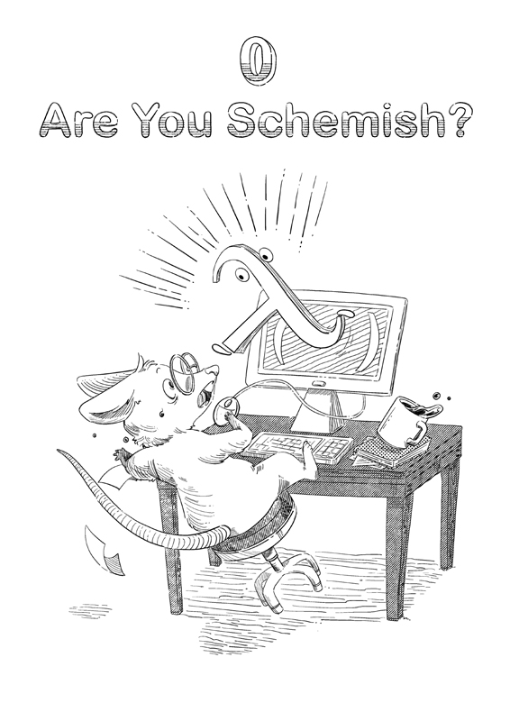

Psst. Psst. Psst!

<sup>1</sup>

Toto, I have a feeling we're not in Kansas anymore.†

†Thanks, Lyman Frank Baum (1856–1919) and thanks, Edgar Allan Woolf (1881–1943).

How about a quick review?

<sup>2</sup>

Of what?

Of the programming language we're using here.

<sup>3</sup>

Oh, that would be great.

Did you read the three-page preface?

<sup>4</sup>

Of course, no one should skip the preface

it has a little poem for learning

and

the desserts sound enticing

So, off to reread the preface.†

†Text laid out in this style, where punctuation is replaced by indentation, is a *nugget*.

Those who already know Scheme† can zip through this to the next chapter, *The Lines Sleep Tonight*, after briefly glancing at the table on page xxiii for perhaps a few familiar names.

<sup>5</sup>

Thanks.

†Thanks, John McCarthy (1927–2011), Gerald Jay Sussman (1947–), and Guy L. Steele Jr. (1954–).

Let's first learn how to give names to values

(**define** *pie*† 3.14)

†It's not the tastiest *pie* we could find; it's missing the meringue topping (i.e., more digits after the 4).

<sup>6</sup>

Does that give the name *pie* to the number 3.14?

Yes, it does.

Here are some more definitions

(**define** *a-radius* 8.4)

(**define** *an-area*

(* *pie*

(* *a-radius a-radius*)))

<sup>7</sup>

Assuming * the multiplication function, does this mean *an-area* is

221.5584

Correct.

Functions are invoked with zero or more arguments

(⟨*function*⟩ ⟨*argument*⟩ *. . .*)

Since all mathematical operations (such as *, +, etc.) are functions, they are also written in this way.

<sup>8</sup>

How can we make new functions?

Let's make a function of one *formal*

*r*

Formals are the names given to arguments that are passed in when the function is invoked

(λ (*r*)

(* *pie*

(* *r r*)))

In this expression, λ (also written **lambda**) marks the beginning of a new function. Then we have the formals. Here we have a single formal *r*. And then we have the *body* of the function, which is the expression for the value of the function.

What does this function produce?

<sup>9</sup>

It squares the argument *r* and multiplies it with *pie*. That looks like the area of a circle with radius *r*.

Does this function have a name?

No, it doesn't.

But we can give it one using **define**

(**define** *area-of-circle*

(λ (*r*)

(* *pie*

(* *r r*))))

<sup>10</sup>

Aha.

λ is used to create a function and **define** is used to give it a name.

So, are functions also values?

Yes.

Functions are also values and they can be used like other values.

<sup>11</sup>

Does that mean that functions can result in other functions?

Yes, it does.

Here is an example

(**define** *area-of-rectangle*

(λ (*width*)

(λ (*height*)

(* *width height*))))

What is

(*area-of-rectangle* 3.0)?

<sup>12</sup>

The function *area-of-rectangle* is a function with one formal. But it results in a function

(λ (*height*)

(* *width height*))

Does it not?

Very close.

The extra bit of information we need to remember is that *width* inside this function already has a value of 3.0.

This is how to think about it

(λ (*height*)

(* 3.0 *height*))

<sup>13</sup>

That is a neat trick.

The inner function *remembers* the argument passed in for the formal of the outer function.

Can we also pass functions in as arguments to other functions?

Indeed, we can.

Here is an example

(**define** *double-result-of-f*

(λ (*f* )

(λ (*z*)

(* 2 (*f z*)))))

Explain how *f* is being used here.

<sup>14</sup>

Here *f* is a formal of *double-result-of-f*, and then *f* is later invoked on *z*.

This means *f* must be a function.

Correct.

Here's a function that adds 3 to its formal

(**define** *add3*

(λ (*x*)

(+ 3 *x*)))

What happens when we invoke

*double-result-of-f* on the *add3* function?

(*double-result-of-f add3*)

<sup>15</sup>

When we invoke *double-result-of-f* on *add3*, we get the inner function.

We remember the argument passed in for the formal *f* from the outer function, which means that we remember that *f* must have been *add3*.

Very good.

We write it this way

(λ (*z*)

(* 2 (*add3 z*)))

What happens when we invoke this function on the argument 4?

((λ (*z*)

(* 2 (*add3 z*)))

4)

<sup>16</sup>

The value of *z* inside this function is now 4, so we get

(* 2 (*add3* 4))

Great.

What about the rest of it?

<sup>17</sup>

The expression

(*add3* 4)

is the same as

((λ (*x*)

(+ 3 *x*))

4)

which gets us 7. Substituting this into our previous expression, we get

(* 2 7)

giving us 14.

Correct.

This way of remembering arguments passed in for formals of outer functions inside inner functions is known as *β*-substitution.†

This is a useful tool for understanding function invocation. Scheme, in reality, has better ways of doing *β*-substitution.

†Thanks, Alonzo Church (1903–1995).

Care also must be taken when doing *β*-substitution so that all the names in the definition are unique at every step. If not, formals of functions can be given new names to make sure they are always unique.

<sup>18</sup>

Is **define** also a function?

No, it is not.

It is a *keyword*. Expressions that begin with keywords are known as *special forms*. They are different from function invocations.

<sup>19</sup>

Is λ also a keyword?

Yes. Here is an example of another special form

(**cond**

((= *pie* 4) 28)

((*< pie* 4) 33)

(**else** 17))

This expression results in 33.

Explain why.

<sup>20</sup>

The keyword here is **cond**†.

Is **cond** short for *conditional*?

†Also known as McCarthy's **cond**.

Yes, it is.

<sup>21</sup>

So then

(= *pie* 4)

and

(*< pie* 4)

must be tests.

Yes, they are.

<sup>22</sup>

Since *pie* is not equal to 4, the first test fails† but the second test succeeds.‡

†It results in false, written in Scheme as **#**f.

‡It results in true, written in Scheme as **#**t.

Correct.

Each combination of test and value is known as a *clause*, where **else** is treated as true. The value of the **cond** expression is the value of the first clause with a true test, checking them from the top to the bottom.

<sup>23</sup>

The **cond** expression results in 33, because its associated test is the first one that is true.

Very good.

Let's combine these three special forms we have just learned

(**define** *abs*

(λ (*x*)

(**cond**

((*< x* 0) (*−* 0 *x*))

(**else** *x*))))

Explain what *abs* does.

<sup>24</sup>

It is the absolute value function!

It takes a single number *x* and if the number is *less than* 0, it subtracts this negative number from 0, and it results in a positive number.

Else, it results in the nonnegative number

*x*

We also need a way to define *local names* inside our functions, where these names are not visible outside those functions.

<sup>25</sup>

Yes, that should be useful for defining readable functions.

We do that using a special form known as a **let**-expression. For example

(**define** *silly-abs*

(λ (x)

(**let** ((*x-is-negative* (< *x* 0)))

(**cond**

(*x-is-negative* (− 0 *x*))

(**else** *x*)))))

<sup>26</sup>

It looks as if we are giving

(*< x* 0)

the local name

*x-is-negative*

Yes, we are.

The last expression of the **let** (in this example the **cond**) is known as the *body* of the **let**. Of course, it does not always have to be a **cond**. It can be any expression. The name *x-is-negative* can be used anywhere inside the body of the **let**-expression, but it has no value outside of it.

<sup>27</sup>

That's convenient.

Perfect.

We have everything we need.

<sup>28</sup>

No we don't. We still haven't seen loops.

Our language does not have loops.

<sup>29</sup>

What?

How can we define interesting functions without loops?

We use *recursive functions*.

<sup>30</sup>

Is that where the body of a function refers to the name given to the function itself?

Precisely.

Let's define a simple version of the remainder function.†

Here's an example of how it would work. Suppose we want to find the remainder where the two numbers are 13 and 4. The remainder is what's left over after removing as many 4s from 13 as possible.

What is the result here?

†It's simple because we assume its first argument to be a nonnegative number and its second argument to be positive.

<sup>31</sup>

The remainder is 1, since we can remove 4 three times from 13, to get 1.

Correct.

Let's do it step by step. Since 13 is larger than 4, we can remove 4 to get 9.

What is the next step?

<sup>32</sup>

The number 9 is also larger than 4, so we can remove it one more time to get 5.

Good.

The number 5 is still larger than 4, so we can remove it one last time to get 1.

<sup>33</sup>

Now it is smaller than 4, and we can no longer remove 4 from it.

So the remainder is 1.

Excellent.

Find expressions that go inside the boxes labelled *X* and *R*.

<sup>34</sup>

To find the remainder, we must first check if we can remove *y* from *x*. This is possible only when *x* is greater than or equal to *y*.

If, however, *x* is less than *y*, then *x* must be the remainder. So, when

(*< x y*)

this function results in *x*. So, *X* is *x*.

What happens if *x* is not less than *y*?

Then, we can remove *y* from *x* once, and continue by finding the remainder of the result.

<sup>35</sup>

Ah, so we must find the remainder of (*− x y*) and *y*

Correct.

We do this by recursively invoking *remainder*.

<sup>36</sup>

This means *R* is

(*remainder* (*− x y*) *y*)

Excellent.

Here, then, is *remainder*

(**define** *remainder*

(λ (*x y*)

(**cond**

((< *x y*) *x*)

(**else** (*remainder* (− *x y*) *y*)))))

<sup>37</sup>

Is there a common pattern to help us define recursive functions?

Yes, there is.

Each recursive function tests its arguments to see if they meet a base test requirement. We refer to this test as the *base test*. We refer to the resultant value as the *base value*.

What are the base test and base value here?

<sup>38</sup>

The first clause in the **cond** is

(*< x y*), the base test

and

*x*, the base value

Is there a name for the second clause?

Yes.

It is known as the *recursive* case.

<sup>39</sup>

Could we see another example?

Sure.

The argument *n* is the first number and the argument *m* is the second one.

We must find *T*, *V*, and *R*, but first describe what the base test of such a function would be.

†Another name for nonnegative integers, defined as having a 0 and *add1* defined on them.

<sup>40</sup>

The base test would be if one of the numbers is zero, since we're looking only at natural numbers.

Does this mean we have two base tests?

It could, but it is not necessary.

Since the order of the arguments to addition does not matter, we can, with no loss of generality, restrict our base test to just the second number.

What would the base value be?

<sup>41</sup>

The base value would be the first number, since adding any number to 0 gives us back that number.

That's a good start.

We can now fill in *T* and *V*.

Show the revised skeleton. Use the function *zero?*, which tests whether its argument is zero.

<sup>42</sup>

Correct.

Now let us look at *R*. If *m* is not zero, we can say that it is some number

(*k* + 1)

where *k* is a natural number.

What results when we add *k* + 1 and *n*?

<sup>43</sup>

We get

(*k* + 1) + *n*

Good.

We can rewrite this as

(*k* + *n*) + 1

<sup>44</sup>

How can that insight help us?

For natural numbers, we can always assume that a function *add1* exists that results in *k* + 1 when given *k*.

And similarly, a function *sub1* exists that results in *k* when given *k* + 1.

<sup>45</sup>

Where does that lead us?

*R* must, as in frame 44, result in

(*k* + *n*) + 1

We already have *n*, so how do we get *k* from *m*?

<sup>46</sup>

Since *m* is *k* + 1, we can get *k* using (*sub1 m*)

Perfect.

And *R* must add 1 to the addition of *k* (which is (*sub1 m*)) and *n*.

<sup>47</sup>

So should *R* have this form?

(*add1* **…** *addition of n* **and** (*sub1 m*) **…**)

Absolutely.

Now we have this insight.

Since *n* and (*sub1 m*) are also natural numbers, we can get their addition by invoking *add* on them!

<sup>48</sup>

Amazing!

So *R* must be

(*add1* (*add n* (*sub1 m*)))

Right!

Show the final *add*.

<sup>49</sup>

Here it is

(**define** *add*

(λ (*n m*)

(**cond**

((*zero? m*) *n*)

(**else** (*add1* (*add n* (*sub1 m*)))))))

Great.

Let's look at our example with 7 and 2

(*add* 7 2)

What happens next?

<sup>50</sup>

Since 2 is not *zero?*, we are in the recursive case. So, our result should be

(*add1* (*add* 7 (*sub1* 2)))

which is the same as the result of

(*add1* (*add* 7 1))

Correct.

Since the second argument to add in this recursive invocation is 1 (i.e., not zero), we can further rewrite this as

(*add1* (*add1* (*add* 7 (*sub1* 1))))

which is the same as

(*add1* (*add1* (*add* 7 0)))

<sup>51</sup>

Now our second argument is zero, so

(*add* 7 0)

gives us

7

Correct.

Now we can invoke the two wrapped *add1*s on 7

(*add1* (*add1* 7))

to get

(*add1* 8)

which is

9

<sup>52</sup>

And that is our result!

More succintly, we can describe this behavior in a same-as chart†

1. 1. (*add* 7 2)
2. 2. (*add1* (*add* 7 (*sub1* 2)))
3. 3. (*add1* (*add* 7 1))
4. 4. (*add1* (*add1* (*add* 7 (*sub1* 1))))
5. 5. (*add1* (*add1* (*add* 7 0)))
6. 6. (*add1* (*add1* 7))
7. 7. (*add1* 8)
8. 8. 9

So, there are seven steps besides the one that is the original problem

(*add* 7 2)

and by carefully going from one expression to the next, which always has the same value, we simplify the result to

9

Now try

(*remainder* 13 4)

†The same-as chart, introduced in *The Little Typer* (2018) p. 69, uses a *solid* vertical line on the left and shows expressions that are the same as one another.

<sup>53</sup>

These are fun, but not as much as a chocolate fudge banana split, right?

1. 1. (*remainder* 13 4)
2. 2. (*remainder* (*−* 13 4) 4)
3. 3. (*remainder* 9 4)
4. 4. (*remainder* (*−* 9 4) 4)
5. 5. (*remainder* 5 4)
6. 6. (*remainder* (*−* 5 4) 4)
7. 7. (*remainder* 1 4)
8. 8. 1

Debatable!

In both our examples, we have at least one argument *shrinking* and heading towards the base test.

<sup>54</sup>

Is this true of all recursive functions?

Yes, if we expect the recursive function to result in a value.

In general, when we're defining a recursive function, we should follow this sequence of steps

Figure out the base test

figure out the base value

find out how the arguments to the recursive invocation change, especially those that shrink

and

use the recursive invocation as part of a larger expression to obtain the overall result of the function.

We refer to the portion of the expression excluding the recursive invocation as its *wrapper*.†

†In the definition of *add*, this is the portion between “(*add1*” and the “)” that matches it.

<sup>55</sup>

Still, just a bit squeamish.

Did you *meet every character*?

<sup>56</sup>

Yes, and the ones in the framenotes.

Okay, then.

We have everything we need to get started.

The rest we'll learn along the way.

<sup>57</sup>

Exciting!

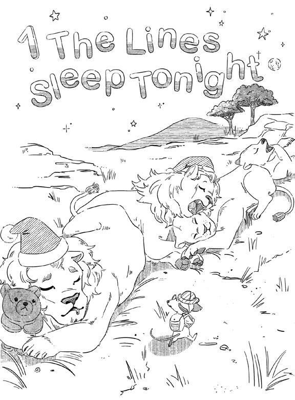

†With apologies and thanks to Solomon Ntsele (1909–1962).

Welcome back!

<sup>1</sup>

It's good to be here!

Indeed.

Remember this?

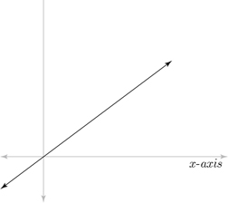

<sup>2</sup>

Yes.

That looks like a line in plane (2-dimensional) geometry along with two additional lines, the *x*-axis and the *y*-axis.†

†Thanks, René Descartes (1596–1650).

There is an *equation* that relates *x* with *y* for every point (*x, y*) on a line

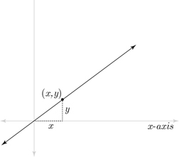

<sup>3</sup>

Does using arrows at both ends of the line mean that it extends indefinitely in both directions and does it follow that there is a corresponding *y* for every *x*?

Yes.

Our line passes through the *origin*.

<sup>4</sup>

What is the origin?

The point at which the *x*-axis and the *y*-axis meet is known as the *origin* and is the point (0, 0). The dark line in the picture passes through the origin.

<sup>5</sup>

So what is the equation of this line?

Because this line passes through the origin, *y* is a multiple of *x* by a constant factor *w*, which is known as the *slope* of the line

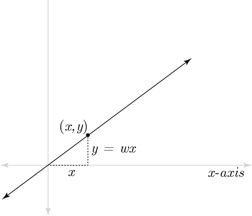

<sup>6</sup>

Does that mean *y* = *wx?*

Yes, it does.

<sup>7</sup>

What if the line does not go through the origin?

Good question. This is what it would look like

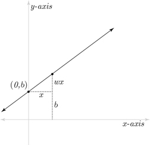

How can we determine *y*?

<sup>8</sup>

It appears that the whole line is lifted by *b* now.

We can determine *y* for any *x* using

*y* = *wx* + *b*†

†*y* = *mx* + *b* might be more familiar.

Here is our first attempt at *line*†

(**define** *line*

(λ (*x*)

(λ (*w b*)

(**let** ((*y* (+ (* *w* *x*) *b*)))

*y*))))

†The dashes on the left indicate that this dashed definition of *line* is not yet final. As attempts are made, these dashes may never disappear or they may eventually turn into a final box, black or red.

<sup>9</sup>

This is a function of one argument that results in a function of two arguments?‡

This dashed definition of *line* seems backwards. Why don't we require *w* and *b* before *x*?

‡If this is confusing, consider rereading the chapter *Are You Schemish?*.

Great question!

That kind of definition assumes that *w* and *b* are known *prior to* the argument *x*.

Here, though, we deal with a different kind of problem, where *x* is known, but *w* and *b* must be figured out from a bunch of given values of *x* and *y*.

<sup>10</sup>

Why isn't *line* final?

That's because our next attempt can simplify *line* a little more. Since the body of the **let**, *y*, is only the name given to

(+ (* *w* *x*) *b*)

by the **let**, we get this *same-as* chart†

1. 1. (**let** ((*y* (+ (* *w* *x*) *b*)))
2. *y*)
3. 2. (+ (* *w* *x*) *b*)

Even though there is no longer a *y* here, we sometimes refer to this value as the *y* associated with a given *x*.

<sup>11</sup>

So, this dashed definition should be our next attempt to finalize *line*

(**define** *line*

(λ (*x*)

(λ (*w b*)

(+ (* *w* *x*) *b*))))

It looks correct, so why is *line* still dashed?

†Introduced in frame 16:53.

Good question.

This *line* is still dashed because we are going to make another attempt soon. But for now, it suffices.

Because *w* and *b* are used to determine the *y* corresponding to a given *x*, they are considered to be a special kind of formal. We name them *parameters* of *line*, and we use bold letters for them, whereas *x* is the *argument* of *line*.

<sup>12</sup>

How is the function *line* used?

Let's see an example.

What is

(*line* 8)?

<sup>13</sup>

(*line* 8) is a function that remembers that *x* is 8, and is waiting to accept arguments for its parameters *w* and *b*

(λ (*w b*)

(+ (* *w* 8) *b*))

That is correct.

When (*line* 8) is invoked on *w* and *b*, we can determine *y*.

What is

((*line* 8) 4 6)?

<sup>14</sup>

Here are the steps with *w* being 4 and *b* being 6

1. 1. ((*line* 8) 4 6)
2. 2. ((λ (*w b*)
3. (+ (* *w* 8) *b*))
4. 4 6)
5. 3. (+ (* 4 8) 6)
6. 4. (+ 32 6)
7. 5. 38

This means that when *x* is 8, *y* is 38.

Excellent.

Functions that accept parameters *after* the arguments are known as

*parameterized functions*

Is *line* a parameterized function?

Yes.

It takes *w* and *b* as its parameters after it takes the argument *x*.

Why are parameterized functions special?

Good question.

Parameterized functions are used where we must figure out the right values for the parameters (here, *w* and *b*) from given values of *x* and the corresponding values of *y*.

Could we see an example?

Sure.

Here *line-xs* are the *x*-coordinates and *line-ys* are the *y*-coordinates

(**define** *line-xs*

[2.0 1.0 4.0 3.0])

(**define** *line-ys*

[1.8 1.2 4.2 3.3])

For each *x*-coordinate in *line-xs*, there is a corresponding *y*-coordinate in *line-ys* and vice versa.

<sup>17</sup>

Do *line-xs* and *line-ys*, when taken together, give us these four *points*?

- (2.0, 1.8)
- (1.0, 1.2)
- (4.0, 4.2)
- (3.0, 3.3)

Yes.

Together, they form a *data set*.

<sup>18</sup>

Okay.

Here is how the data set

(*line-xs*, *line-ys*)

looks as points on a graph

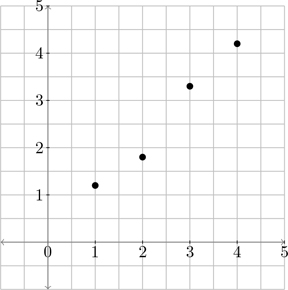

<sup>19</sup>

Those points look like they are *almost* on a straight line.

For good reason.

Draw a line that is close enough to these four points.

<sup>20</sup>

How about this?

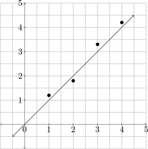

Yes, that is close enough.

Lines, as in frame 11, have two parameters, *w* and *b*.

What are *w* and *b* for this line?

<sup>21</sup>

Since this line passes through the origin, *b* is 0.0.

And, the *x* and *y* coordinates of every point *on this line* are always equal. For example, (0.0, 0.0), (1.2, 1.2), etc. The points on this line look like (*a*, *a*), for any *x*-coordinate *a*.

So, *w* must be 1.0.

That is correct.

This function is simply a line with parameters

*w* = 1.0

and

*b* = 0.0

How can we use this information?

<sup>22</sup>

If we are given a new *x*-coordinate, we can *predict* the corresponding *y*-coordinate from this line.

For example, if *x* = 3.79, then

*y* = 1.0 *×* 3.79 + 0.0 = 3.79

## The Rule of Parameters

(Initial Version)

Every parameter is a number.

Correct.

We refer to this as the *predicted y* for a given *x*.

Finding the parameters of a function from a data set is known as *learning*.

<sup>23</sup>

So we have *learned* a function that behaves approximately like the points given by the data set

(*line-xs*, *line-ys*)

The parameters *w* and *b* here are collectively known as the *parameter set*, which we refer to as *θ*.†

So, our *θ* has two parameters. They are referred to as *members* of *θ*.

Then *w* is the first member of *θ*, which we write as *θ*<sub>0</sub>.‡

†Pronounced “little theta.”

‡Members are indexed beginning at 0.

<sup>24</sup>

Is *b* then *θ*<sub>1</sub>?

It is.

Let's rewrite *line* to reflect this

(**define** *line* •

(λ (*x*)

(λ (*θ*)

(+ (* θ<sub>0</sub> *x*) *θ*<sub>1</sub>))))

<sup>25</sup>

Why is this *line* in a red-colored box with a red-colored circle?

Good question.

We have chosen red boxes and circles to highlight final definitions that are *important* as well as sometimes being primitive.†

†The circle is for those who might have trouble distinguishing red lines from black lines.

<sup>26</sup>

Red is such a vibrant color for a toy. How do we construct a *θ* for *w* and *b*?

Great question.

Here's an example. If *w* is 1.0 and *b* is 0.0, we construct it this way

(**list** 1.0 0.0)

<sup>27</sup>

So *θ* is a *list* of members such that

*θ*<sub>0</sub>

which is the same as *w* is

1.0

and

*θ*<sub>1</sub>

which is the same as *b* is

0.0

Here's an example of how *line* is invoked with this *θ*

1. 1. ((*line* 7.3) (**list** 1.0 0.0))
2. 2. ((λ (*θ*)
3. (+ (* *θ*<sub>0</sub> 7.3) *θ*<sub>1</sub>))
4. (**list** 1.0 0.0))

Complete this same-as chart.

<sup>28</sup>

Sure

1. 3. (+ (* (**list** 1.0 0.0)<sub>0</sub> 7.3) (**list** 1.0 0.0)<sub>1</sub>)
2. 4. (+ (* 1.0 7.3) 0.0)
3. 5. 7.3

Correct.

So far, we have examined our data set on a graph and estimated a *θ*.

<sup>29</sup>

And we used it to predict a

*y*-coordinate

for an

*x*-coordinate

that may not be in our data set.

In other words, we have *learned* from an existing data set how to make *y*-coordinate predictions for *x*-coordinates.

<sup>30</sup>

Yes, we have learned something!

Still, we have accomplished this by visually inspecting only the points on the graph.

<sup>31</sup>

Can we define a function that determines *θ* for any data set?

An excellent question.

Yes, we can, and such a function is an example of what is known as *machine learning*.† But that's what the rest of the book is about!

†There are many forms of machine learning. Here we cover only one form.

<sup>32</sup>

It's a good time to take a break.

## **Toy Chest**

(*line-xs*, *line-ys*) 24

*line*, 26

*l<sub>i</sub>* (where *l* is a list and *i* is a zero-based index) 26

(**list** *m* …) (where *m* … are its members) 26

**Let’s take that break!**

**How about some butterscotch ice cream?**

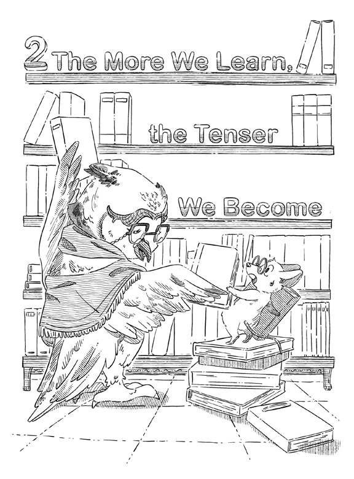

We can still taste the luxurious creamy butterscotch.

<sup>1</sup>

Mmm *. . .* fantastic!

Is 5 a natural number?

<sup>2</sup>

Yes.

It is a nonnegative integer.

What about 0?

<sup>3</sup>

Yes.

It is a natural number.

Is *−*5 a natural number?

<sup>4</sup>

No.

Natural numbers cannot be negative.

What is 7.18?

<sup>5</sup>

That's a *real* number.

Is *−*13.713 also real?

<sup>6</sup>

Yes, it is.

Are all natural numbers also real numbers?

Yes, we consider them to be.

There is another name we use for all real numbers here. We refer to them as

*scalars*

<sup>7</sup>

Is 7.18 a scalar?

Yes.

What is *π*†?

†This *π* is much tastier than the *pie* from frame 3:6 because *π* has lots of meringue on it!

<sup>8</sup>

Like 3.141592653589793 *. . .*? Then, *π* is also a scalar.

Correct.

The predicate *scalar?* tests whether something is a scalar and like all predicates is a function that *always* results in a Boolean—either false #f or true #t.†

†Thanks, George Boole (1815–1864).

<sup>9</sup>

Okay.

Here is a *tensor*<sup>1</sup>.† A tensor<sup>1</sup> has only scalars

[5.0 7.18 *π*]

†Pronounced “tensor one.”

<sup>10</sup>

Is that a superscript on the word *tensor*‡?

‡Thanks, Woldemar Voigt (1850–1919), Gregorio Ricci-Curbastro (1853–1925), Tullio Levi-Civita (1873–1941), and for popularizing, thanks, Albert Einstein (1879–1955).

Yes, it is.

A tensor<sup>1</sup> groups one or more scalars together†

[2.0 1.0 4.0 3.0]

†A tensor1 can be thought of as a “*vector*” or a “*one-dimensional* ” array.

Here, the empty tensor does not exist.

<sup>11</sup>

These bracketed scalars seem familiar!

They should be, that's *line-xs* from frame 24:17.

Here is another example

[8]

<sup>12</sup>

This tensor<sup>1</sup> contains the scalar 8.

Is there a tensor<sup>2</sup>†?

†Pronounced “tensor two.”

Yes, the *element*s of a tensor<sup>2</sup> are tensors<sup>1</sup>.†

†A tensor<sup>2</sup> can be thought of as a “*matrix*” or a *“two-dimensional”* array.

<sup>13</sup>

What is an element?

For example

[[7 6 2 5] [3 8 6 9] [9 4 8 5]]

has 3 elements

[7 6 2 5]

[3 8 6 9]

and

[9 4 8 5]

<sup>14</sup>

Then if we have a tensor whose elements are tensors*<sup>m</sup>*, does that make it a tensor*<sup>m</sup>*<sup>+1</sup>?

Yes, but there's a condition.

All the tensors*<sup>m</sup>* must have the same number of elements.

<sup>15</sup>

That seems reasonable.

What can we say about the 3 tensors<sup>1</sup> in frame 14?

<sup>16</sup>

Each has 4 elements and each of those elements is a scalar.

For example

How about

<sup>17</sup>

This is it

Yes, it is.

<sup>18</sup>

Is this

[[[[8]]]]

also a tensor?

Yes, the tensor

[[[[8]]]]

is a tensor<sup>4</sup> of an element

[[[8]]]

which is a tensor<sup>3</sup> of an element

[[8]]

which is a tensor<sup>2</sup> of an element

[8]

which is a tensor<sup>1</sup> of an element

8

which is a scalar.

What is

[[5 6 4] [9 1 1] [0 6 2]]?

<sup>19</sup>

It looks like a tensor<sup>2</sup> whose three elements are tensors<sup>1</sup>.

Is this

[[[5] [6] [7]] [[8] [9] [0]]]

possible?

Yes, the tensor

[[[5] [6] [7]] [[8] [9] [0]]]

is a tensor<sup>3</sup> of

2 tensor<sup>2</sup> elements

each of those 2 elements has

3 tensor<sup>1</sup> elements

each of those 3 elements has

1 single element

a scalar.

<sup>20</sup>

Since a tensor*<sup>m</sup>*<sup>+1</sup> must have only tensors*<sup>m</sup>* elements, a tensor<sup>1</sup> should be made up of tensor<sup>0</sup> elements.

Does that mean a scalar is a tensor<sup>0</sup>?

Great question.

Yes, a scalar like 9 *is* a tensor<sup>0</sup>.†

†But, “*zero-dimensional* ” arrays are rarely, if ever, mentioned.

<sup>21</sup>

Does the superscript have a name?

Yes, it does.

It is known as the *rank* of the tensor.

<sup>22</sup>

What does the rank of a tensor mean?

The rank of a tensor tells us how deeply nested its elements are.

†We can determine the rank of a tensor by counting the number of left square brackets before the leftmost scalar (here 8).

<sup>23</sup>

It appears we can define a function to determine the rank of a tensor.

## The Rule of Rank

A tensor's rank is the number of left square brackets before its leftmost scalar.

Indeed, we can.

Before that, though, let's look at how to reach into a tensor to look at its elements. The operation†

*t|<sub>i</sub>*

picks out the ith element of the tensor.

So, for example, t|<sub>0</sub> gets the 0th (first) element of the tensor.

†Pronounced “*tensor-ref t i*.”

<sup>24</sup>

How do we use this to find the rank of a tensor?

Here is a function that finds the rank of a tensor

(**define** *rank*

(λ (*t*)

(**cond**

((*scalar? t*) 0)

(**else** (*add1* (*rank t|*<sub>0</sub>))†))))

Here, *t*|<sub>0</sub> is the 0th element of *t*, which always exists because we have already determined that *t* is not a scalar, and furthermore the 0th element is itself a tensor.

Now explain *rank*.

†The “(*add1*” and its matching “)” is a *wrapper* of the recursive invocation (*rank t|*<sub>0</sub>).

This form of recursive function, where we follow the structure of its argument, is known as a *naturally recursive* function. See *The Little LISPer* (1974) p. 21 or *The Little Schemer* (1996) p. 45.

See frame 13:42 for *zero?*, and frame 14:45 for *add1* and *sub1*.

<sup>25</sup>

If the base test,‡ (*scalar? t*), succeeds then we know the rank of the tensor is 0.

In general, if the elements of a tensor are tensors*<sup>m</sup>*, then the tensor has rank

*m* + 1

So, in the recursive case, we find

*m*

which is the rank of the 0th element of *t*

(*rank t|*<sub>0</sub>)

and then *add1* to the result to get the rank of *t*.

Could we see how *rank* is 3 with the tensor in frame 23 using a same-as chart?

‡If this term is unfamiliar, see chapter 0.

Sure.

Given the same tensor from frame 23 [[[8] [9]] [[4] [7]]] here is a same-as chart that shows how its *rank* is 3

1. 1. (*rank* [[[8] [9]] [[4] [7]]])
2. 2. (*add1* (*rank* [[8] [9]]))
3. 3. (*add1* (*add1* (*rank* [8])))
4. 4. (*add1* (*add1* (*add1* (*rank* 8))))
5. 5. (*add1* (*add1* (*add1* 0)))
6. 6. (*add1* (*add1* 1))
7. 7. (*add1* 2)
8. 8. 3

<sup>26</sup>

That is so elegant and natural.

There's another observation here. We need look only at

*t|*<sub>0</sub>

i.e., only the first element of the tensor.

<sup>27</sup>

Yes, why is that?

That is because in any given tensor, the nested tensors have the same number of elements. For example, the nested tensors of tensors<sup>2</sup> are all tensors<sup>1</sup>, and each of those tensors<sup>1</sup> has the same number of tensors<sup>0</sup>.

<sup>28</sup>

That's the requirement from frame 15.

Correct.

This means that the tensors*<sup>m</sup>* that are elements of a tensor*<sup>m</sup>*<sup>+1</sup> have the same *shape*.

<sup>29</sup>

What is the shape of a tensor?

The shape of

[[5.2 6.3 8.0] [6.9 7.1 0.5]]

is this list of positive natural numbers

(**list** 2 3)†

Where do those natural numbers come from?

†We sometimes underline portions of an expression to draw attention to them.

<sup>30</sup>

This tensor is a tensor<sup>2</sup> of 2 tensors<sup>1</sup>, each of which has 3 tensor<sup>0</sup> elements.

Exactly.

What is the shape of

[[[5] [6] [8]] [[7] [9] [5]]]?

<sup>31</sup>

The shape of

[[[5] [6] [8]] [[7] [9] [5]]]

is

(**list** 2 3 1)

Right again.

[[[5] [6] [8]] [[7] [9] [5]]]

is a tensor<sup>3</sup> of

2 tensor<sup>2</sup> elements

Each of those has

3 tensor<sup>1</sup> elements

Each of those has

1 tensor<sup>0</sup> element

which is a scalar.

What is the shape of

[9 4 7 8 0 1]?

<sup>32</sup>

[9 4 7 8 0 1] is a tensor<sup>1</sup> of 6 scalars.

So, is

(**list** 6)

the shape of

[9 4 7 8 0 1]?

That is correct.

<sup>33</sup>

Do scalars have a shape?

They do.

Since scalars have no parts, their shape is the empty list.

<sup>34</sup>

How do we write empty lists?

Like this

(**list**)

<sup>35</sup>

So the shape of the scalar 9 is

(**list**)?

Correct.

To find the shape of a tensor *t*, we need to know the number of elements it has.

<sup>36</sup>

We do!

Here is the function *shape* that finds the shape of a given tensor *t*

(**define** *shape* •

(λ (*t*)

(**cond**

Explain this *shape*.

†The “(*cons* ” and its matching “)” is a wrapper of (*shape t|*<sub>0</sub>). Compare *rank*'s wrapper in frame 25.

<sup>37</sup>

But wait, what is *cons*?‡

‡Some might remember “CONS The Magnificent” on p. 17 of *The Little LISPer.*

## The Rule of Members and Elements

Non-empty lists have members and non-scalar tensors have elements.

The function *cons* takes two arguments, a value *v* and a list *l*, and produces a new list by adding

*v*

to the front of

*l*

For example

1. 1. (*cons* 3 (**list** 7 9))
2. 2. (**list** 3 7 9)

Now, please explain *shape*.

<sup>38</sup>

When the argument to *shape*, *t*, is a scalar, its shape is simply the empty list.

Otherwise, it is a non-scalar tensor, so we find the 0th element's shape, which is a list, by recursively invoking *shape* thusly

(*shape t|*<sub>0</sub>)

Correct.

What is

(*shape* 9)?

<sup>39</sup>

(*shape* 9) is the empty list because 9 is a scalar.

What is

(*shape* [9 4 7 8 0 1])?

<sup>40</sup>

(*shape* [9 4 7 8 0 1]) is

(*cons* 6 (*shape* 9))

which is

(**list** 6)

## The Rule of Uniform Shape

All elements of a tensor must have the same shape.

Using a same-as chart, determine (*shape t*) where *t* is

[[[5] [6] [8]] [[7] [9] [5]]]

from frame 31.

<sup>41</sup>

Here it is

1. 1. (*shape* [[[5] [6] [8]] [[7] [9] [5]]])
2. 2. (*cons* 2 (*shape* [[5] [6] [8]]))
3. 3. (*cons* 2 (*cons* 3 (*shape* [5])))
4. 4. (*cons* 2 (*cons* 3 (*cons* 1 (*shape* 5))))
5. 5. (*cons* 2 (*cons* 3 (*cons* 1 (**list**))))
6. 6. (*cons* 2 (*cons* 3 (**list** 1)))
7. 7. (*cons* 2 (**list** 3 1))
8. 8. (**list** 2 3 1)

The number of members in a list *ls* is

*|ls|*

How are rank and shape related?

<sup>42</sup>

Aha!

The number of members in the shape of a tensor† is also the rank of the tensor

(= *|*(*shape t*)*|* (*rank t*))

†We can also use a tensor's shape to determine its total number of scalars by taking the product of its shape's members.

## The Law of Rank and Shape

The rank of a tensor is equal to the length of its shape.

There's one more definition we need to look at.

<sup>43</sup>

Can't wait.

Here's our final way to define *rank*, but this one is already *unwrapped*, i.e., no recursive invocation is wrapped!

(**define** *rank* •

(λ (*t*)

(*ranked t* 0)))

(**define** *ranked*

(λ (*t a*)

(**cond**

((*scalar? t*) *a*)

(**else** (*ranked t*|<sub>0</sub> (*add1 a*))))))

This *rank* definition uses a support function *ranked* that includes an additional formal *a* as an *accumulator*.

To see how it works, repeat the example in frame 26 but using this final *rank*.

<sup>44</sup>

Here it is

1. 1. (*rank* [[[8] [9]] [[4] [7]]])
2. 2. (*ranked* [[[8] [9]] [[4] [7]]] 0)
3. 3. (*ranked* [[8] [9]] (*add1* 0))
4. 4. (*ranked* [[8] [9]] 1)
5. 5. (*ranked* [8] (*add1* 1))
6. 6. (*ranked* [8] 2)
7. 7. (*ranked* 8 (*add1* 2))
8. 8. (*ranked* 8 3)
9. 9. 3

Instead of a wrapper around the recursive invocation of

*rank*

we

*add1*

to the accumulator

*a*

as we are going down into

*t|*<sub>0</sub>

That is correct.

<sup>45</sup>

Thanks!

Seeing this way of using t*|*<sub>0</sub> as an argument in an unwrapped recursive invocation helps.

Unlike the dashed *rank* in frame 25, this new recursive function definition does *not* use a wrapper.

In fact, this matters so much that we have a law about it.

<sup>46</sup>

Let's see it.

## The Law of Simple Accumulator Passing

In a simple accumulator passing function definition every recursive function invocation is unwrapped, and the definition has at most one argument that **does not change**; an argument that **changes towards a true** base test; and another that **accumulates** a result.

| This Law of Simple Accumulator Passing is important. | <sup>47</sup> | Why? |
| --- | --- | --- |
| This law enables us to handle very large tensors and lists. | <sup>48</sup> | How? |
| When combining simple accumulator passing function definitions, they could be thought of as one very big *loop*. | <sup>49</sup> | How is that possible? |
| Every Scheme system is required to support *tail call optimization* which makes each unwrapped recursive invocation behave the same as a loop. | <sup>50</sup> | How do the other requirements in the law help? |
| The other requirements ensure that we use a uniform pattern for our function definitions so that they are easy to read and understand. | <sup>51</sup> | These simple accumulator passing function definitions seem to offer great possibilities! |
| Now it is time for a break! | <sup>52</sup> | It is just what is needed. Things were getting intense. |

## Tensor Toys

*scalar?* 32

[*e es* …] (where *e es* … are its elements) 33

33

*t*|*<sub>i</sub>* 36

*shape* 39

*scons* 40

*|ls|* 41

*rank* 42

**Let's line up for something delicious.**

**How about some boba tea?**

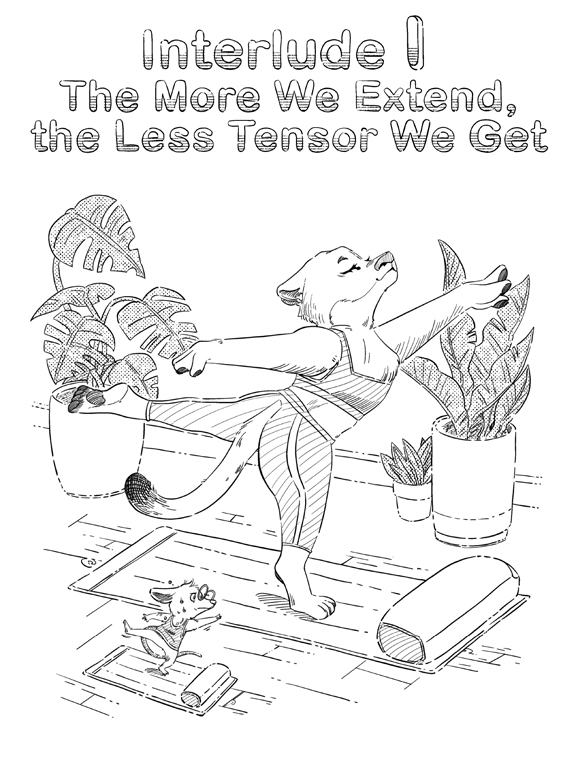

The tea?

<sup>1</sup>

Boba with mango jelly, scrumptious!

How about an interlude?

<sup>2</sup>

What's an interlude?

It's where we temporarily shift our focus.

<sup>3</sup>

To what?

To have more fun with +.

<sup>4</sup>

That's addition, right?

Yes.

What is (+ 1 1)?

<sup>5</sup>

That's easy

(+ 1 1)

is

2†

†Thanks, Alfred North Whitehead (1861–1947) and Bertrand Arthur William Russell (1872–1970).

Thank goodness.

What is

(+ [2] [7])?

<sup>6</sup>

That's tricky. The arguments are tensors<sup>1</sup>.

Is

(+ [2] [7])

the same as

[9]?

Yes, but why is that?

Here is a same-as chart to discover how the chart results in [9]

1. 1. (+ [2] [7])
2. 2. [(+ 2 7)]
3. 3. [9]

<sup>7</sup>

Why are those brackets turquoise?

When there is a function invocation like + on tensors, we use turquoise brackets to emphasize that we're going to look inside those tensors to help determine the invocation's final value.

What is

(+ [5 6 7] [2 0 1])?

<sup>8</sup>

Is

(+ [5 6 7] [2 0 1])

the same as

[7 6 8]?

Here is the same-as chart that shows how to get that result

1. 1. (+ [5 6 7] [2 0 1])
2. 2. [(+ 5 2) (+ 6 0) (+ 7 1)]
3. 3. [7 6 8]

<sup>9</sup>

It appears that + descends into its

tensor<sup>1</sup> arguments

to result in another tensor<sup>1</sup>.

The last step results in the tensor<sup>1</sup> of the values of the three sums.

Yes.

<sup>10</sup>

Must we have tensors of the same shape before we can add them?

Yes, we must.

Getting + to work on tensors of arbitrary rank is known as

the *extension*† of +.

Functions built using extension are known as *extended* functions. Can other functions that work on scalars be extended similarly?

†Also known as *pointwise* extension.

<sup>11</sup>

It would appear so.

There is nothing special about +. Other extended scalar functions should work in the same way.

Here's another way extension works.

What is

(+ 4 [3 6 5])?

<sup>12</sup>

But these two tensors don't have the same shape!

Correct.

When that happens, we do this

1. 1. (+ 4 [3 6 5])
2. 2. [(+ 4 3) (+ 4 6) (+ 4 5)]

Finish this same-as chart.

<sup>13</sup>

Oh, we look inside the tensor<sup>1</sup> argument and repeatedly add 4 to each element.

The final answer is

1. 3. [7 10 9]

Very good.

How about this?

1. 1. (+ [6 9 1] [[4 3 8] [7 4 7]])

<sup>14</sup>

We can look inside the tensor<sup>2</sup> argument and add the tensor<sup>1</sup> argument to each element, just as we did in frame 13

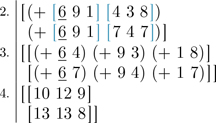

Excellent.

Let us now take an

extended version of *

This is *The Hadamard* † *multiplication.*

Now this one

1. 1. (* [[4 6 5] [6 9 7]] 3)

†Thanks, Jacques Salomon Hadamard (1865–1963).

<sup>15</sup>

Let's look at another extended function

*sqrt*†

1. 1. (*sqrt* 9)
2. 2. 3

†The function *sqrt* must always result in a nonnegative square root.

<sup>16</sup>

Applying *sqrt* to the scalar 9 gets its square root, which is 3.

Now let's invoke *sqrt* on

[9 16 25]

This time the rank of the argument is 1. So *sqrt* descends into the tensor<sup>1</sup>

1. 1. (*sqrt* [9 16 25])
2. 2. [(*sqrt* 9) (*sqrt* 16) (*sqrt* 25)]
3. 3. [3 4 5]

<sup>17</sup>

The *sqrt* function has been invoked on each scalar in the tensor<sup>1</sup>.

In these same-as charts, again, the tensor that is to be descended into is marked with turquoise brackets.

<sup>18</sup>

Could we see another example?

Sure.

Here is an example of how *sqrt* behaves on a tensor<sup>2</sup>

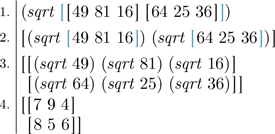

<sup>19</sup>

It seems as if *sqrt* descends into each tensor<sup>1</sup> of the argument until it finds the tensors<sup>0</sup> and gets their square roots.

Yes, descending into a tensor is a trick we use often.

With a higher-rank tensor, the process would repeat itself until we encounter scalars and get their square roots.

<sup>20</sup>

That makes sense.

Can we treat functions of two arguments in a similar way?

Yes, we can.

We now know how extended functions of two arguments can be made to work when the two arguments have different ranks by descending into the higher-ranked tensor.

<sup>21</sup>

Do extended functions always descend until they find scalars?

Some don't.

To see that, let's look at a new function

*sum*<sup>1</sup>

And this is how we expect it to behave

1. 1. (*sum*<sup>1</sup> [10.0 12.0 14.0])
2. 2. 36.0

<sup>22</sup>

It looks as if it is summing the scalars in a tensor<sup>1</sup>.

But why do we have a superscript 1 on *sum*?

The superscript is a reminder that *sum*<sup>1</sup> expects a tensor<sup>1</sup>.†

Now that we know that *sum*<sup>1</sup> *always* takes a tensor<sup>1</sup>, let's define it.

†We use this superscript convention for other functions, too.

<sup>23</sup>

That sounds interesting.

Here is *sum*<sup>1</sup>

(**define** *sum*<sup>1</sup> •

(λ (*t*)

(**define** *summed*

(λ (*t i a*)†

(**cond**

((*zero? i*) (+ *t*|<sub>0</sub> *a*))

(**else**

(*summed t* (*sub1 i*) (+ *t*|*<sub>i</sub> a*))))))

Explain *sum*<sup>1</sup>.

†Here is how we place our formals for a simple accumulator passing function definition. If there is one that **does not change**, like *t*, it is the first formal; the one that **accumulates**, like *a*, is the last formal; and the one that **changes towards a true** base test, like *i*, is to the accumulator's left. See, for example, *rank* on page 42.

<sup>24</sup>

We invoke the support function *summed* with the tensor

*t*

the last index in *t*

and an accumulator starting at

0.0

The function *summed* counts the index *i* down to zero. At each step it adds the *i*th element in the tensor *t* to the accumulator, and recursively invokes *summed*.

And finally, when we reach the 0th element in the tensor, we add that element to the accumulator which results in the sum of the entire tensor.

We refer to the extended version of *sum*<sup>1</sup> as *sum*, which descends into its argument until it finds a tensor<sup>1</sup> instead of a tensor<sup>0</sup>.

<sup>25</sup>

How does *sum* work?

Here is *sum* working on a tensor<sup>3</sup>

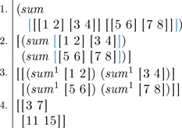

What can we say about the rank of this result?

<sup>26</sup>

This is a tensor<sup>2</sup>, so its rank is 2, which means that the rank is 1 less than the rank of the input, which is also true for *sum*<sup>1</sup>.

## The Law of Sum

For a tensor *t* with rank *r* > 0, the rank of (*sum t*) is *r −* 1.

Yes.

This is a useful property of *sum* that we rely on later.

<sup>27</sup>

What about functions that are constructed from these extended functions?

A great question.

If we use extended functions to form new functions, then the new functions also automatically work in an extended fashion.

<sup>28</sup>

Could we see an example of this?

Sure.

Here is such an example.

What is

((*line* [2 7 5 11]) (**list** 4 6))?

<sup>29</sup>

We're invoking *line* on a tensor<sup>1</sup> argument.

Does that mean the functions + and * in *line* are extended functions?

It does!

Here, we want to find *y* values for many (here, four) *x* values on the line with *θ*<sub>0</sub> being 4 and *θ*<sub>1</sub> being 6.

<sup>30</sup>

Magnificent!

Finish the same-as chart to determine the corresponding four predicted *y*s

1. 1. ((*line* [2 7 5 11]) (**list** 4 6))

<sup>31</sup>

Here goes

1. 2. ((λ (*θ*)
2. (+ (* *θ*<sub>0</sub> [2 7 5 11]) *θ*<sub>1</sub>))
3. (**list** 4 6))
4. 3. (+ (* 4 [2 7 5 11]) 6)
5. 4. (+ [(* 4 2) (* 4 7) (* 4 5) (* 4 11)] 6)
6. 5. (+ [8 28 20 44] 6)
7. 6. [(+ 8 6) (+ 28 6) (+ 20 6) (+ 44 6)]
8. 7. [14 34 26 50]

This interlude is about how it is possible to extend functions that operate on fixed ranks of tensors into functions that also accept tensors of different ranks. We use the concept of *descending* into the higher-ranked tensors to accomplish this.

<sup>32</sup>

And we have learned that by doing this, we descend into the higher-ranked tensor while repeating the lower-ranked tensor until the one- or two-argument operation can proceed.

## Extendy Toys

*sum* 53

**How about some cappuccino?**

**With some beignets?**

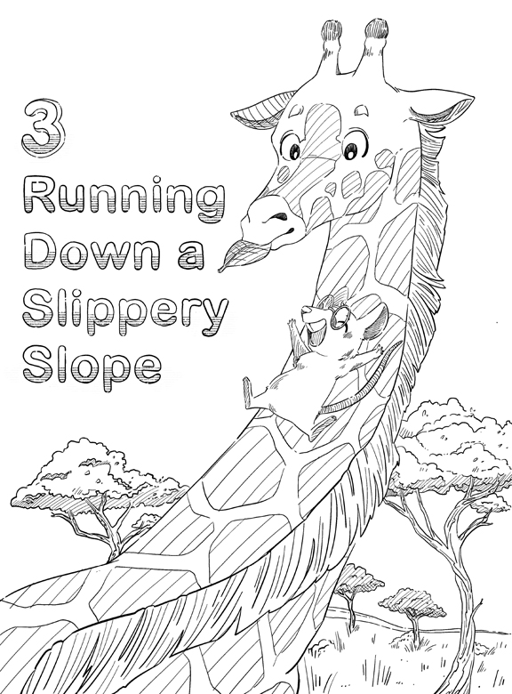

How was the cappuccino?

<sup>1</sup>

The beignets went great with it.†

†Thanks, *Café du Monde* (1862–), New Orleans.

Let us now return to defining a function to automatically find the *θ* that best fits (from frame 27:29) the given data set in 24:17. We refer to this *θ* as *well fitted*.

<sup>2</sup>

Just as we visually fit a line to match our points from frame 25:20?

Exactly.

Here we introduce

*successive approximations*†

†Thanks, Joseph Raphson (c.1648–c.1715).

<sup>3</sup>

Are successive approximations a way to find a well-fitted *θ*?

Yes.

We determine *θ*<sub>0</sub> and *θ*<sub>1</sub> by arbitrarily starting them at 0.0. We then repeatedly revise *θ* to bring it as close as we wish to what it must finally be.†

†Successive approximation is a family of methods in mathematics, another one of which may be familiar to some as being a method to determine the roots of a polynomial such as a square root. Thanks, Sir Isaac Newton (1643–1727) and Joseph Raphson.

<sup>4</sup>

An example, please.

Sure.

Here is the data set from frame 24:17

*line-xs* is [2.0 1.0 4.0 3.0]

and

*line-ys* is [1.8 1.2 4.2 3.3]

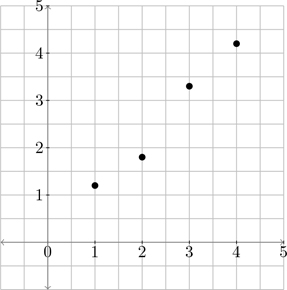

<sup>5</sup>

So then do we start with

*θ*<sub>0</sub> = 0.0

and

*θ*<sub>1</sub> = 0.0?

That is a fine place to start.

What line does this *θ* give us?

<sup>6</sup>

We can find out by using (**list** 0.0 0.0) as *θ*

1. 1. ((*line line-xs*) **θ**)
2. 2. ((*line* [2.0 1.0 4.0 3.0]) (**list** 0.0 0.0))
3. 3. (+ (* 0.0 [2.0 1.0 4.0 3.0]) 0.0)
4. 4. [0.0 0.0 0.0 0.0]

The *y*-coordinates produced for the *x*-coordinates in *line-xs* are all 0.0. So this *θ* represents the *x*-axis!

Indeed it does.

Those values, which we refer to as the *predicted ys* from frame 26:23, are very different from the given *line-ys*!

<sup>7</sup>

What does this mean?

It means that *θ*<sub>0</sub> and *θ*<sub>1</sub> do not yet *fit* our data set.

<sup>8</sup>

Do we have to revise *θ*<sub>0</sub> and *θ*<sub>1</sub> to bring the predicted *ys* closer to the given *line-ys*?

Yes, we do.

But, in order to do that, we need to know how far away we are from the well-fitted *θ*.

We need a *single* scalar that tells us how close or how far away we are. This scalar is known as the *loss*.† The well-fitted *θ* would be the one where this loss is as close to 0.0 as possible.

When the loss *is* 0.0, it is *ideal.*

†This is also known as *cost*.

<sup>9</sup>

Why can't it be a tensor<sup>1</sup>?

With a scalar, it is simpler to decide how to revise *θ*.

<sup>10</sup>

How is this scalar used?

We determine this scalar, or loss, every time we revise *θ*. Since the loss shows us how far away we are from the well-fitted *θ*, we use it as a guide for revising *θ*.

<sup>11</sup>

How do we find the loss for a given *θ* ?

We'll define a function for it, of course!

But we'll do it in two steps. First we determine a tensor representing how far away we are and then reduce this tensor down to a scalar.

Find *P*.

<sup>12</sup>

*P* must be the predicted *ys*. So, *P* must be

((*line line-xs*) (**list** *θ*<sub>0</sub> *θ*<sub>1</sub>))

Correct.

This gives us

(*− line-ys* ((*line line-xs*) (**list** *θ*<sub>0</sub> *θ*<sub>1</sub>)))

It, however, is not yet a scalar. It is still a tensor<sup>1</sup>, so we must turn it into a scalar.

What function, which we have already defined, derives a scalar from a tensor<sup>1</sup>?

<sup>13</sup>

That function is *sum* from frame 53:25.

Is this

(*sum*

(− *line-ys* ((*line line-xs*) (**list** *θ*<sub>0</sub> *θ*<sub>1</sub>))))

how we find the scalar?

Almost, but it is not good enough.

Here's why. Suppose we had another data set and another *θ* that would have given us a difference of

[4.0 *−*3.0 0.0 *−*4.0 3.0]

What would be the result of

(*sum*

[4.0 *−*3.0 0.0 *−*4.0 3.0])?

<sup>14</sup>

It would be 0.0, the ideal loss, which it clearly is *not*!

So, even though the individual differences are very high, the sum of 0.0 suggests that the *θ* is a *perfect fit.*

Aha! This problem arises from having negative values in the argument to *sum*.

So what should we do?

We solve this by squaring each element.† This turns the negative elements of the difference to positive, and the positive elements stay positive

(*sum*

(*sqr*

(*− line-ys* ((*line line-xs*) (**list** *θ*<sub>0</sub> *θ*<sub>1</sub>)))))

Here, the (extended *−*) descends into the two tensors<sup>1</sup> resulting in a tensor<sup>1</sup> of differences, then *sqr* squares the resultant tensor<sup>1</sup> of differences, yielding a tensor<sup>1</sup> for *sum* to produce a scalar.

Now the sum of the squares is positive if *at least* one of the elements in the difference is non-zero.

<sup>15</sup>

That's a promising strategy.

How should we define our loss function?

†Other functions, such as *abs* (i.e., absolute value) from frame 9:24 work, but we use only squaring here because it works better in most situations.

Here is a function that does this

(**define** *l2-loss*

(λ (*xs ys*)

(λ (*θ*)

(**let** ((*pred-ys*† ((*line xs*) *θ*)))

(*sum*

(*sqr*

(− *ys pred-ys*)))))))

†The predicted *ys* is named *pred-ys*.

<sup>16</sup>

Why is this function named *l2-loss*?

It is an instance of a family of functions that use exponents to find the loss. Here, since we use *sqr* (i.e., raised to the power of 2), this loss function is *l2-loss*.†

†In mathematics, the square root of the sum of the squares of a tensor<sup>1</sup> is known as *L2-norm*. The *L2-norm* is also known as *Euclidean* distance. Thanks, Euclid of Alexandria (325bce–270bce).

<sup>17</sup>

Why is this definition dashed?

When used as a loss function, however, the square root is typically left out. Another variant of this loss function divides the sum of the squares by the number of elements in the tensor to produce a *mean squared error* (or *MSE*) loss function.

Because we're going to generalize *l2-loss*.

This *l2-loss* relies on *line*. But, as far as this *l2-loss* is concerned, *line* is just some function that results in a predicted *ys*, *pred-ys*, when given *xs* and *θ*.

<sup>18</sup>

How can we use this observation?

We can make *l2-loss* less specific to *line*, so we can use it with other functions as well. We redefine *l2-loss* to take *line* as an argument

(**define** *l2-loss*

(λ (*line*)

(λ (*xs ys*)

(λ (*θ*)

(**let** ((*pred-ys* ((*line xs*) *θ*)))

(*sum*

(*sqr*

(− *ys pred-ys*))))))))

<sup>19</sup>

Why is *this l2-loss* dashed?

This *l2-loss* is dashed because the name *line* is too specific.

Since we have made *line* into a formal, the name no longer represents the original *line* function. So, we should rename the formal *line* to something more meaningful.

<sup>20</sup>

So what name should we pick?

Here, the function *line* is referred to as a *target* function because that is the function whose *θ* we are trying to find for a given data set.

So, instead of the name *line*, let's use the name *target*.†

<sup>21</sup>

Sounds better.

†This process, briefly touched upon in frame 7:18, is known as *α*-substitution and dictates how the formals of a λ-expression may be properly renamed. Thanks, Alonzo Church.

Here is how we define the final *l2-loss* to use the name *target* instead of *line*

(**define** *l2-loss* •

(λ (*target*)

(λ (*xs ys*)

(λ (*θ*)

(**let** ((*pred-ys* ((*target xs*) *θ*)))

(*sum*

(*sqr*

(*− ys pred-ys*))))))))

<sup>22</sup>

Aha!

<sup>23</sup>

We should invoke *l2-loss* with *line*

(*l2-loss line*)

Correct.

Here's the same-as chart for this

1. 1. (*l2-loss line*)
2. 2. (λ (*xs ys*)
3. (λ (*θ*)
4. (**let** ((*pred-ys* ((*line xs*) *θ*))
5. (*sum*
6. (*sqr*
7. (− *ys pred-ys*))))))

This function, which is produced when *l2-loss* is invoked with a target function, is referred to as an *expectant* function.

<sup>24</sup>

Why do we refer to

(λ (*xs ys*) *. . .*)

as an

*expectant* function?

That's because it is *expecting* a data set as arguments.

<sup>25</sup>

That makes sense.

What does an expectant function produce when it receives a data set?

Let's find out

1. 1. ((*l2-loss line*) *line-xs line-ys*)
2. (λ (*θ*)
3. (**let** ((*pred-ys* ((*line line-xs*) *θ*)))
4. (*sum*
5. (*sqr*
6. (− *line-ys pred-ys*)))))

This function, which awaits a *θ* as its argument, is known as an

*objective* function

<sup>26</sup>

What does the objective function do?

When provided with a *θ*, the objective function produces a scalar representing the loss, which is a measure of how far away we are from the well-fitted *θ*.

<sup>27</sup>

So, it is going to help us achieve our objective of finding a well-fitted *θ*!

Let's try it with our current *θ*<sub>0</sub> and *θ*<sub>1</sub> which are still 0.0

(((*l2-loss line*) *line-xs line-ys*)

(**list** 0.0 0.0))

Looking at the final *l2-loss* in frame 22, we must first determine *pred-ys*, which is

((*target xs*) *θ*)

Use the ideas in the same-as chart from frame 55:31 to help find *pred-ys* for *line-xs* and our *θ*.

<sup>28</sup>

Since the value of *target* here is the function *line*, *pred-ys* is determined by

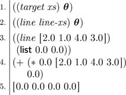

Great.

Keeping this value of *pred-ys* in mind, we find the *loss* for this *θ*

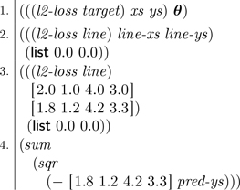

Complete this same-as chart.

<sup>29</sup>

Here it is

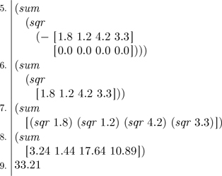

The loss tells us how far away we are and 33.21 tells us we are quite far away.

How do we revise our *θ* to get the scalar loss 33.21 closer to the ideal loss, 0.0?

We begin by testing the behavior of *θ*<sub>0</sub> to see how we should revise it; we'll worry about *θ*<sub>1</sub> later.

We change *θ*<sub>0</sub> by increasing it by a small amount, for testing purposes, so that

*θ*<sub>0</sub> = 0.0099

Find the new *pred-ys* for this new *θ*.

<sup>30</sup>

Okay

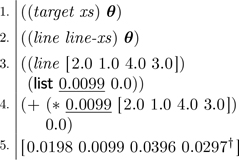

†Scheme systems sometimes produce answers like 0.029700000000000004 due to limitations in the implementation of floating-point numbers. While using same-as charts, we shall round these numbers appropriately.

Perfect.

Here is the same-as chart to find the new loss for this new *θ*<sub>0</sub>

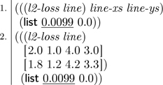

Now, complete this same-as chart.

<sup>31</sup>

Here it is

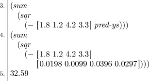

The loss has gone down.

In other words, we are slightly closer to the ideal loss!

We changed the loss by

(32.59 *−* 33.21) = *−*0.62

by revising *θ*<sub>0</sub> from 0.0 to 0.0099.

Our test has succeeded.

<sup>32</sup>

So should we *continue* to revise *θ*<sub>0</sub> in increments of 0.0099 until we come as close as possible to the ideal loss?

It could mean that.

Revising *θ*<sub>0</sub> every time by 0.0099 may require too many revisions to get to the well-fitted *θ*.

There is a way, however, that takes fewer revisions.

<sup>33</sup>

Show us the way!

<sup>34</sup>

†Thanks, Gottfried Wilhelm Leibniz (1646–1716) and thanks, Sir Isaac Newton.

The rate of change is also known as the *derivative*.

The rate of change of a function (here, of the objective function), determines how its result changes when its argument (i.e., *θ*) is revised.

By using the rate of change *cautiously*, we can get to the well-fitted *θ* with fewer revisions.

<sup>35</sup>

What does using it cautiously mean?

This rate of change has a large *absolute value*.† This means that a small *increase* in *θ*<sub>0</sub> causes a relatively large *decrease* in its loss.

We can use this idea to determine how much to further revise *θ*<sub>0</sub> so that we can make an even bigger reduction in loss. But, we must be careful.

<sup>36</sup>

What should we be wary of?

†The absolute value of a scalar, defined as a function in frame 9:24, is its value without its sign. For example, here the absolute value of both *−*62.63 and 62.63 is 62.63.

We have to be wary that our revision of *θ*<sub>0</sub> always moves us closer to, but does not *overshoot*, the ideal loss.

One choice, for example, is to revise *θ*<sub>0</sub> by 62.63, which is the absolute value of the whole rate of change. When we do this, however, we end up with a

loss of 113763.027

This is far bigger than 32.59, which is our previous loss, and much greater than the ideal loss.

<sup>37</sup>

That is something to be wary of indeed.

How do we solve this problem?

We take a small scalar (like 0.01), and multiply the rate of change by it, and revise *θ*<sub>0</sub> by that amount.

<sup>38</sup>

So we get

0.01 *× −*62.63 = *−*0.6263

Is this a small enough revision that won't overshoot the ideal loss?

Yes, it should be.

This small scalar is known as the

*learning rate*

Since we use this scalar often, we have a special symbol for it

*α*†

We rewrite our example thusly

*α × −*62.63 = *−*0.6263

†The learning rate (usually a very small number between 0.0 and 0.01) is also known as the *step size*. We'll see more of how to find an appropriate learning rate in later chapters.

The step size is sometimes written as λ, but because we already have a meaning for λ, we prefer to use a different Greek letter.

<sup>39</sup>

Okay.

Since we need to *increase* *θ*<sub>0</sub> to reduce the loss, we must *subtract* this negative value from our current *θ*<sub>0</sub>. So the new *θ*<sub>0</sub> is

0.0 *− −*0.6263 = 0.6263.

<sup>40</sup>

But, didn't we set *θ*<sub>0</sub> to 0.0099?

That was just to find the rate of change.

Once we find the rate of change, we forget about 0.0099.

<sup>41</sup>

Okay.

So we revise by multiplying the learning rate and the rate of change and then subtracting the result from our current

*θ*<sub>0</sub>?

## The Law of Revision

(Initial Version)

new *θ*<sub>0</sub> = *θ*<sub>0</sub> *−* (*α ×* rate of change of loss with respect to *θ*<sub>0</sub>)

Exactly!

We proceed, as before, by finding the new *pred-ys* for the new *θ*<sub>0</sub>

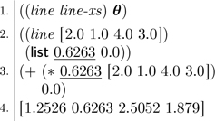

Now find the loss.

<sup>42</sup>

We use this new *pred-ys* to find the loss

[figure not shown]

We have gone from a loss of 33.21 to a loss of 5.52. That is so much better than just increasing *θ*<sub>0</sub> by 0.0099 as we did in frame 30!

Amazing. We've taken a big step closer to the ideal loss now.

We repeat this process to get our next revision.

<sup>43</sup>

Can we subtract *−*0.6263 from *θ*<sub>0</sub> again?

No, we cannot!

Let's find out what the rate of change of loss is with *θ*<sub>0</sub> at 0.6263. Let us give

((*l2-loss line*) *line-xs line-ys*)

the temporary name *obj*. Then the rate of change is

[figure not shown]

<sup>44</sup>

It's different from the rate of change we found in frame 34.

Does this mean that the rate of change depends on the *current* *θ*<sub>0</sub>?

That is exactly what it means.

<sup>45</sup>

So do we determine the rate of change again using *θ*<sub>0</sub> + 0.0099?

We could.

But there is a much better way—one that is simpler and more precise.

<sup>46</sup>

That sounds exciting.

What is this new way?

That's what we'll discover in the next chapter, where we also find out how to revise *θ*<sub>1</sub>!

<sup>47</sup>

What's the best snack to help prepare for that next chapter?

## Lossy Toys

*l2-loss* 63

**How about a chocolate chip cookie?**

**Be sure to cautiously dust the crumbs away!**

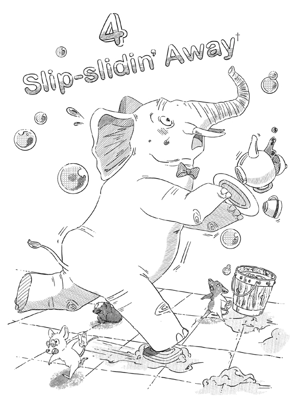

†Thanks, Paul Frederic Simon (1941–).

And the cookie?

Ready?

<sup>1</sup>

That's the way it crumbles.

Let's roll!

We start with a picture

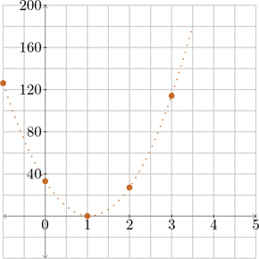

<sup>2</sup>

This graph looks different, what is it?

It is a graph of the loss in our example against *θ*<sub>0</sub> while keeping *θ*<sub>1</sub> at 0.0. The *y*-axis here represents the loss, and the *x*-axis represents *θ*<sub>0</sub>, which we also refer to as *weight*.

<sup>3</sup>

So, for any possible value of the weight, this graph shows the corresponding value of the loss.

What are the big orange dots?

To draw this picture, we choose five weights *−*1.0, 0.0, 1.0, 2.0, and 3.0.

(*line-xs*, *line-ys*)

The orange dots represent the losses at each of these weights.

<sup>4</sup>

How can we find these five losses?

First, let's take a deeper look at our objective function

((*l2-loss line*) *line-xs line-ys*)

Show a same-as chart that expands it.

<sup>5</sup>

Here it is

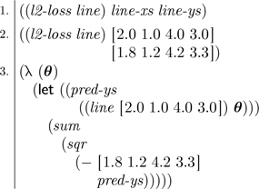

Great.

Let us name this λ-expression *obj*, for objective function, from frame 64:26.

Explain how we can use *obj* to determine the losses.

<sup>6</sup>

The λ-expression *obj* takes the parameters of a line as its argument and results in a scalar representing how closely that line fits the data set (i.e., the loss).

So we must construct a *θ* with each of those five weights as *θ*<sub>0</sub> and 0.0 as *θ*<sub>1</sub>. The corresponding losses would be

- (*obj* (**list** *−*1.0 0.0)), which is 126.21
- (*obj* (**list** 0.0 0.0)), which is 33.21
- (*obj* (**list** 1.0 0.0)), which is 0.21
- (*obj* (**list** 2.0 0.0)), which is 27.21
- (*obj* (**list** 3.0 0.0)), which is 114.21

Correct.

We use this orange style of graph to show quantities that are *not* part of our data set.

What is our initial estimate for *θ*<sub>0</sub>?

<sup>7</sup>

It is 0.0.

The loss when *θ*<sub>0</sub> is 0.0 (and keeping *θ*<sub>1</sub> at 0.0) is 33.21 from frame 65:29.

The point (0.0, 33.21) is circled in this graph

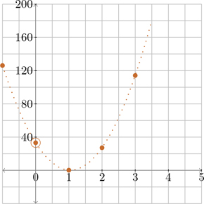

<sup>8</sup>

Aha!

So the loss seems to be the lowest at the bottom of this curve.†

†The bottom of this curve in this graph visually appears to be at 0.0 of the *y*-axis, but this rarely happens. Depending upon the data set, the bottom is usually higher than 0.0.

Correct.

We need to “roll” down this incline to get to its bottom, and from frame 67:37, we have discovered that we can use the rate of change to roll down faster than we could before without overshooting.

<sup>9</sup>

How can we represent rates of change on this graph?

Here is how we do it for our initial estimate with *θ*<sub>0</sub> being 0.0

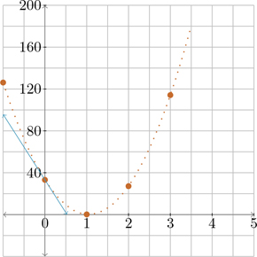

<sup>10</sup>

What is the turquoise colored line?

That turquoise line is different from the line for which we are trying to find *θ*<sub>0</sub> and *θ*<sub>1</sub>. This line is known as a *tangent*.

A tangent touches the *loss* curve at exactly one point.

<sup>11</sup>

Is that point (0.0, 33.21)?

Yes, it is.

The rate of change that we have determined is the

*slope of the tangent*

This slope has a different name so we don't confuse it with *θ*<sub>0</sub>. It is known as the

*gradient*

<sup>12</sup>

Here are the tangents for our first two estimates of *θ*<sub>0</sub>

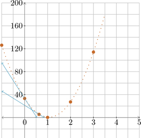

Describe what's interesting about this graph.

<sup>13</sup>

We see that the tangent for our second *θ*<sub>0</sub> is less steep than the tangent for our first *θ*<sub>0</sub>. Thus, the gradient of the second is lower than the gradient of the first.

These are only for *θ*<sub>0</sub>, but we must also have them for *θ*<sub>1</sub>.

Is there something similar for *θ*<sub>1</sub>?

Well done.

A gradient is a general way of understanding the rate of change of a parameterized function with respect to *all* its parameters.

<sup>14</sup>

How can we find this gradient?

To find the gradient of a function at given values of its arguments, we need to use a new function ∇. The first argument to ∇ is a function *f* that takes a list of tensors, including *θ*s. The second argument to ∇ is *the list* for which we need gradients of *f*.

<sup>15</sup>

Does this function then result in the gradients?

Yes.†

The result of ∇ is a list of gradients of *f* with respect to each parameter in *θ*, and is referred to as the *gradient list*.

So, for example, if we want the gradient of *f* with respect to parameters *u* and *v*, we write it

(∇ *f* (**list** *u v*))

<sup>16</sup>

How about an example?

†Those familiar with *automatic differentiation* may recognize that the (partial) derivatives of the function with respect to a given set of arguments are automatically determined.

Thanks, William Kingdon Clifford (1845–1879), thanks, Robert Edwin Wengert (1922–2001), and thanks, Lev Nikolayevich Korolev (1926–2016), L. M. Beda, T. S. Frolova, and N. V. Sukhikh.

That's a great idea.

Let's find the gradient of *sqr* with respect to its argument at 27.0

1. 1. (∇ (λ (*θ*) (*sqr* *θ*<sub>0</sub>)) (**list** 27.0))
2. 2. (**list** 54.0)

The first argument to ∇ is a function that expects a *θ* containing a single parameter, and it squares that single tensor using *sqr*. The second argument is the *θ* containing the parameter 27.0. This expresses the gradient of *sqr* at the scalar 27.0.†

<sup>17</sup>

Instead of these lists, couldn't we directly use scalars here?

†Those familiar with gradients should recognize that the gradient of *x*<sup>2</sup> at any value *x*, is *2x*.

The inner workings of ∇ can be found in the appendix *Ghost in the Machine* on page 351.

Some may observe that if ∇ were to take arguments one at a time (in other words, were we to *Curry* it), then (∇ *f* ) would be equivalent to the mathematical definition of the gradient of *f*. Here, however, we define it with two arguments for simplicity.

Thanks, Moses Schönfinkel (1889–1942) and Haskell Brooks Curry (1900–1982)

A great question.

While using scalars directly without packaging them in a list would make sense for simple examples, more complex learning problems require a very large collection of parameters.

It is easiest to package them in a list, so we have designed ∇ to work exclusively with lists.

<sup>18</sup>

So, does ∇ always accept a function and a list of parameters and result in a list of gradients, one for each parameter?

Yes, that is correct.

∇ always results in a list of gradients—one for each parameter provided in *θ*.

<sup>19</sup>

How can we use ∇ to determine the gradient of *l2-loss* with respect to

*θ*<sub>0</sub> and *θ*<sub>1</sub>

where each parameter starts out as

0.0?

((*l2-loss line*) *line-xs line-ys*)

at *θ*<sub>0</sub> and *θ*<sub>1</sub> equal to 0.0

<sup>20</sup>

So the gradient of *obj*

with respect to *θ*<sub>0</sub> is *−*63.0

and the gradient of *obj*

with respect to *θ*<sub>1</sub> is *−*21.0

But why is this value

*−*63.0

different from the rate of change

*−*62.63

of

*θ*<sub>0</sub>

from frame 66:34?

An excellent question.

Our way of finding the rate of change in frame 66:34 is an approximation.

∇ yields more precise results and also yields the gradient with respect to *θ*<sub>1</sub> at the same time.

<sup>21</sup>

Now that we have a way to find the rate of change, should we use it repeatedly as we did in frame 69:43 to find the well-fitted *θ* for *obj*?

Indeed! We revise our *θ* using ∇ a little bit at a time, over many revisions.

To do that, let's define an *iteration* function that makes things easier for us.

<sup>22</sup>

Does an iteration function help us repeat a function invocation over and over again?

It does.

Here is a skeleton of a function *revise* that takes a *revision function f*, which does not change, a natural number *revs*, and an accumulator *θ*. It revises *θ* *revs* times, each time yielding a new value for *θ* by invoking *f* on the current value of *θ*

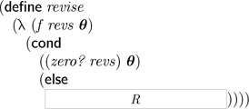

Here, *revs* is the number of revisions of *θ* remaining and *θ* is the value accumulated so far. When *revs* reaches 0, it results in the accumulated *θ*. When *revs* has not counted down to 0, we have *R*, which must revise *θ* once.

Find *R*.

<sup>23</sup>

*R* should recursively invoke *revise* with the new values of *revs* and *θ*. We need to provide a new *θ* by invoking the revision function *f* on *θ*

(*f* *θ*)

Similarly, since we have finished a revision, the new value of *revs* must be

(*sub1 revs*)

Thus, *R* must be

(*revise f* (*sub1 revs*) (*f* *θ*))

Here's *revise*

(**define** *revise* •

(λ (*f revs* *θ*)

(**cond**

((*zero? revs*) *θ*)

(**else**

(*revise f* (*sub1 revs*) (*f* *θ*))))))

<sup>24</sup>

Can we try it out?

Sure.

Using *revise*, write a same-as chart with this revision function *f*

(λ (*θ*)

(*map* (λ (*p*)

(*− p* 3))

*θ*))

this starting *revs*

5

and this initial *θ*

(**list** 1 2 3)

The final *θ* is

(**list** *−*14 *−*13 *−*12)

<sup>25</sup>

What is *map*?

Well-timed question!

In its most specific form *map* accepts a function and a list, and it invokes the function on every member of that list, to produce a new list that is the result of *map*. For example

1. 1. (*map* (λ (*x*)
2. (*add1 x*))
3. (**list** 5 7 3))
4. 2. (**list** (*add1* 5) (*add1* 7) (*add1* 3))
5. 3. (**list** 6 8 4)

<sup>26</sup>

If this is the most specific form, is there a more general form of *map*?

In the more general form *map* accepts more than one list and invokes its function on corresponding members of each list

1. 1. (*map* (λ (*x y*)
2. (+ *x y*))
3. (**list** 12 17 32)
4. (**list** 8 3 11))
5. 2. (**list** (+ 12 8) (+ 17 3) (+ 32 11))
6. 3. (**list** 20 20 43)

<sup>27</sup>

So, in frame 25, invoking *map* on the revision function *f* and *θ* produces a new list where every member is 3 less than the corresponding member of the *θ*.

Here's the start of the same-as chart

1. 1. (*revise f* 5 (**list** 1 2 3))
2. 2. (*revise f* 4 (*f* (**list** 1 2 3)))
3. 3. (*revise f* 4 (**list** *−*2 *−*1 0))
4. 4. (*revise f* 3 (*f* (**list** *−*2 *−*1 0)))
5. 5. (*revise f* 3 (**list** *−*5 *−*4 *−*3))

Now complete the same-as chart.

<sup>28</sup>

Thanks for the hint

1. 6. (*revise f* 2 (*f* (**list** *−*5 *−*4 *−*3)))
2. 7. (*revise f* 2 (**list** *−*8 *−*7 *−*6))
3. 8. (*revise f* 1 (*f* (**list** *−*8 *−*7 *−*6)))
4. 9. (*revise f* 1 (**list** *−*11 *−*10 *−*9))
5. 10. (*revise f* 0 (**list** *−*14 *−*13 *−*12))
6. 11. (**list** *−*14 *−*13 *−*12)

Now let's get back to defining a function that guides us from one *θ* to the next.

The third argument to *revise* must be a list containing the initial values of *θ*<sub>0</sub> and *θ*<sub>1</sub>, in that order.

What would this initial *θ* look like?

<sup>29</sup>

Since we're initializing *θ*<sub>0</sub> and *θ*<sub>1</sub> at 0.0, the initial *θ* should be

(list 0.0 0.0)

Could we see what *f* , this revision function, looks like?

Sure.

Here is a skeleton for this, where *revs* is 1000 and the learning rate *α* is 0.01

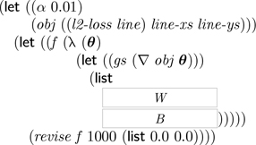

Explain how the invocation of *revise* in this example works.

<sup>30</sup>

We carry out 1000 revisions, starting with (**list** 0.0 0.0) and invoking *f* for each revision.

The revision function accepts an initial *θ* and then produces a different *θ*, and repeats this for 1000 revisions.

Very good.

In the revision function, we determine the gradient of the objective function with respect to *θ*<sub>0</sub> and *θ*<sub>1</sub>, which are packaged into a *θ*.

We use ∇ to get the gradient list *gs*, which is a list of two scalars.

The first is the

gradient of the loss with respect to *θ*<sub>0</sub>

and the second is the

gradient of the loss with respect to *θ*<sub>1</sub>

Now find the expressions for *W* and *B*.

<sup>31</sup>

Since the revision function must produce a new *θ*

*W* should be the new *θ*<sub>0</sub>

and

*B* should be the new *θ*<sub>1</sub>

Correct.

And how do we determine these new members of *θ* i.e., the new parameters?

<sup>32</sup>

We multiply the gradient for a given parameter by the learning rate *α* and subtract it from that parameter.

The gradient with respect to *θ*<sub>0</sub> is given by the 0th member of the gradient list *gs*, which is *gs*<sub>0</sub>. So the expression *W* is

(*−* *θ*<sub>0</sub> (* *α gs*<sub>0</sub>))

Similarly, because the gradient with respect to *θ*<sub>1</sub> is given by *gs*<sub>1</sub>, the expression *B* is

(*−* *θ*<sub>1</sub> (* *α gs*<sub>1</sub>))

Yes, well done.

Here is the completed revision function *f* with *W* and *B* filled in. We show the invocation of *revise* using this new *f* in a *revision* chart.

We use revision charts to show the results after multiple revisions

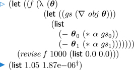

†In Scheme, 1.87e*−*06 is 1.87 *×* 10<sup>−6</sup>, which we consider small enough to be practically 0.0.

<sup>33</sup>

So, this means that after 1000 revisions, we get a reasonably well-fitted *θ*.

What does this line

(**list** 1.05 1.87e*−*06)

look like?

## The Law of Revision

(Final Version)

new *θ**<sub>i</sub>* = *θ**<sub>i</sub> −* (*α ×* rate of change of loss w.r.t. *θ**<sub>i</sub>*)

Here's the line fitted to our original points

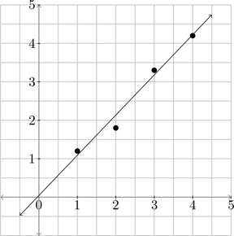

<sup>34</sup>

That's exciting! It is almost identical to the visually estimated line from frame 25:20.

Another question, though. Why do we have *revs* at 1000? Are we certain we'll reach a well-fitted *θ* by then?

A very good question.

We pick a high enough number for *revs* that we know gets us close enough to the well-fitted *θ*.

Depending upon the kind of function we are optimizing, we can pick an appropriate *revs* (usually through a combination of the size of the data set and experimentation).

<sup>35</sup>

That sounds a little ad hoc. Is there a better approach?

Yes, but for only certain kinds of problems.

As we encounter problems with *θ*s that have much larger tensors and target functions that do much more interesting things, a fixed number for *revs* is usually a good approach.

<sup>36</sup>

Does this way of finding *θ*<sub>0</sub> and *θ*<sub>1</sub> have a name?

Yes, it does.

This algorithm is known as

*optimization by gradient descent* †

†Thanks, Augustin-Louis Cauchy (1789–1857).

<sup>37</sup>

Who knew sliding down a slippery slope would be this much fun!

It sure is!

There is one more simplification we can make to our revision function

*f*

Let's look at the expression in our revision function that produces a new *θ*

(**list**

(*−* *θ*<sub>0</sub> (* *α gs*<sub>0</sub>))

(*−* *θ*<sub>1</sub> (* *α gs*<sub>1</sub>)))

<sup>38</sup>

What about it?

This expression is specific to a *θ* that contains exactly two parameters.

<sup>39</sup>

Oh, so it works for target functions (like *line*) that need exactly two parameters in their *θ*s.

Exactly.

In general, we must produce a new *θ* independent of the length of *θ*, and correspondingly of the length of *gs*.

<sup>40</sup>

Can we use *map* here?

Yes, we can.

At each member of *θ* and *gs*, we have to subtract *α* times that member of *gs* from a member of *θ*. We can write this as a function of two arguments where *p* is a member in *θ* and *g* is the corresponding member in *gs*

(λ (*p g*)

(*− p* (* *α g*)))

<sup>41</sup>

Oh, now we *map* this function over

*θ*

and

*gs*

Correct.

We now rewrite the invocation of *revise*

(**let** ((*f* (λ (*θ*)

(**let** ((*gs* (∇ *obj* *θ*)))

(*map* (λ (*p g*)

(*− p* (* *α g*)))

*θ*

*gs*)))))

(*revise f* 1000 (**list** 0.0 0.0)))

<sup>42</sup>

So we have replaced the lines

(**list**

(*−* *θ*<sub>0</sub> (* *α gs*<sub>0</sub>))

(*−* *θ*<sub>1</sub> (* *α gs*<sub>1</sub>)))

with a similar invocation using *map* from frame 25

(*map* (λ (*p g*)

(*− p* (* *α g*)))

*θ*

*gs*)

Yes, correct.

The parameterized function given by

((*l2-loss line*) *line-xs line-ys*)

is the objective function from frame 64:26 because our objective is to find the *θ* that minimizes this function, i.e., that rolls us down the incline to the lowest point, representing the lowest loss.

We now express the complete gradient descent for our data set

(**let** ((*α* 0.01)

(*obj* ((*l2-loss line*) *line-xs line-ys*)))

(**let** ((*f* (λ (*θ*)

(*map* (λ (*p g*)

(− *p* (* *α g*)))

*θ*

(∇ *obj* *θ*)))))

(*revise f* 1000 (**list** 0.0 0.0))))

<sup>43</sup>

Okay.

We are going to make a temporary adjustment. Except for the initial value of *θ*, we have two “*constant* scalars” in this expression

The number of revisions *revs*

and

the learning rate *α*

For now, let's **define** these names

(**define** *revs* 1000)

(**define** *α* 0.01)

How should we now express gradient descent?

<sup>44</sup>

Like this?

(**let** ((*obj* ((*l2-loss line*) *line-xs line-ys*)))

(**let** ((*f* (λ (*θ*)

(*map* (λ (*p g*)

(*− p* (* *α g*)))

*θ*

(∇ *obj* *θ*)))))

(*revise f revs* (**list** 0.0 0.0))))

Excellent!

In this expression, the value of *obj*

((*l2-loss line*) *line-xs line-ys*)

and the initial value of *θ*

(**list** 0.0 0.0)

become arguments to a function named

*gradient-descent*

<sup>45</sup>

Okay.

We now define this algorithm as the function *gradient-descent*. The Θ† is a *renaming* of the formal of *f* from page xxiii

(**define** *gradient-descent*

(λ (*obj* *θ*)

(**let** ((*f* (λ (Θ)

(*map* (λ (*p g*)

(*− p* (* *α g*)))

Θ

(∇ *obj* Θ)))))

(*revise f revs* *θ*))))

This function *gradient-descent* gives us the ability to find the well-fitted *θ*s of many different objective functions with their own *θ*s.

†Prounounced “big theta.”

<sup>46</sup>

And it is what we started out looking for!

What is Θ here?

The Θ is a formal of *f* , the revision function.†

†Again, we have consistently renamed *θ* to Θ, as in frame 62:21.

<sup>47</sup>

Why have we introduced Θ?

Now it seems frivolous, but in fact we have

gr**ate** expectations†

for

Θ

But for now, Θ is simply a name we use for the formal of the revision function.

†Thanks, Charles Dickens (1812–1870) for your *Great Expectations*.

<sup>48</sup>

Okay, for now.

Where can the *initial* *θ* and Θ be found?

<sup>49</sup>

*θ* appears only where we invoke *revise*.

Θ appears only in the revision function.

<sup>50</sup>

We now have a new learning toy!

Yes, we do!

We'll play with it in the upcoming interlude.

<sup>51</sup>

Whew! That's a relief.

## Slippery Toys

∇ 78

*revise* 80

*map* 81

*gradient-descent* (dashed version) 89

**That was quite a slippery slide.**

**Pull yourself up with a tiramisu!**

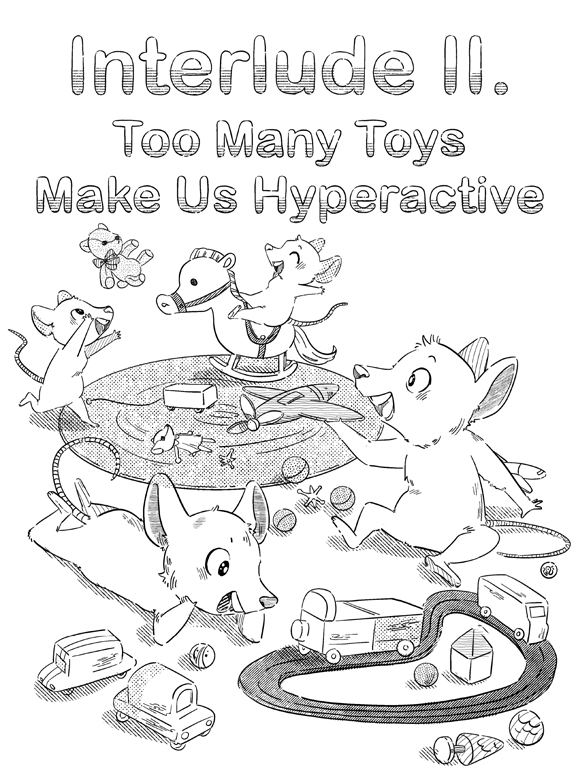

| How was the tiramisu? | <sup>1</sup> | Could not get enough of it. |
| --- | --- | --- |
| This interlude is about *hyperparameters*. | <sup>2</sup> | What are hyperparameters? |
| The temporarily-**define**d names like *revs* and *α* that control the behavior of *gradient-descent* are known as hyperparameters. Hyperparameters are *always* names associated with *scalars* like th… | <sup>3</sup> | Why are they important? |
| These scalars vary by the problem under consideration and must be selected after some thought and experimentation. | <sup>4</sup> | So the scalars that we have picked for *α* and *revs* in *gradient-descent* from chapter 4 may not necessarily work in other situations? |
| That is correct. There are other hyperparameters we encounter later. To make our lives easier when using them, we introduce a new construct. | <sup>5</sup> | Interesting. Can we pack them all up into a list as we did for *θ*? |
| No, a better way would be to treat them as a special kind of name. | <sup>6</sup> | What makes them special? |
| Once these names are declared as hyperparameters, they are available to be used in *any* function. | <sup>7</sup> | Okay. |
| Here is a nonsensical example (**declare-hyper** *smaller*) (**declare-hyper** *larger*) Now, what is (+ *smaller larger*)? | <sup>8</sup> | Because neither *smaller* nor *larger* is associated with a scalar, it has no value. |

## The Rule of Hyperparameters

Every hyperparameter either is a scalar or has no value.

| Yes, that is correct. What is the value of this expression? (**with-hypers** ((*smaller* 1) (*larger* 2000)) (+ *smaller larger*)) | <sup>9</sup> | That should be 2001.† Will either *smaller* or *larger* still be a scalar outside **with-hypers**? †Thanks, Arthur C. Clarke (1917–2008). |
| --- | --- | --- |
| No, they won't. These hyperparameters have scalars associated with them only during **with-hypers** expressions. | <sup>10</sup> | Is **with-hypers** similar to **let**? |
| No, it is not. A **let**-expression creates a new local name for a value, but a **with-hypers** provides a new value for a pre-existing name that has been declared as a hyperparameter. | <sup>11</sup> | That clarifies it! |
| Once these hyperparameters have scalars associated with them by **with-hypers**, those scalars are available to *all* functions using them. After the *body* (+ *smaller larger*) if **with-hypers** has… | <sup>12</sup> | So the hyperparameters are like our **define**d names, but they can be associated with scalars only when set up using **with-hypers**? |
| Yes, correct. Now it gets more interesting. Suppose we define *nonsense?*, this mostly useless function (**define** *nonsense?* (λ (*x*) (= (*sub1 x*) *smaller*))) What is (*nonsense?* 6)? | <sup>13</sup> | Again, it has no value for the very same reason as before. The hyperparameter *smaller* has not yet been provided a scalar. |
| We discover, by providing a scalar for the hyperparameters in use (**with-hypers** ((*smaller* 5)) (*nonsense?* 6)) that the result is #t. To see how this works, imagine that the definition of *nonsen… | <sup>14</sup> | Is (*nonsense?* 6) the body of this **with-hypers**? |
| Yes! Explain how we get this result. | <sup>15</sup> | When *nonsense?* is invoked within **with-hypers**, the scalar *smaller* is 5, so (*nonsense?* 6) results in #t. So why is *nonsense?* dashed? |
| That's because it is silly to use the name *nonsense?* | <sup>16</sup> | Are we going to use hyperparameters in a new *gradient-descent*? |
| Indeed, but that is for the next chapter. | <sup>17</sup> | Can't wait! |

## Hyperactive Toys

**declare-hyper** 94

**with-hypers** 94

**This diversion was too short for a break!**

**Grab another piece of tiramisu!**

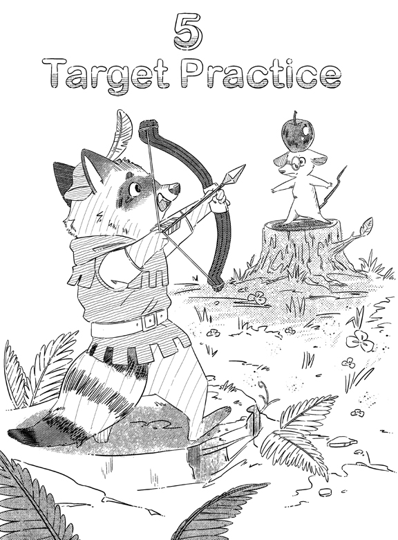

Are we all set to resume?

<sup>1</sup>

Can't wait!

It's time to generalize what we have learned so far.

<sup>2</sup>

Is this where we find out how Θ meets our gr**ate** expectations?

No, we are not there yet, but we are getting closer.

<sup>3</sup>

Where should we start?

Now, we declare two sensible hyperparameters

(**declare-hyper** *revs*) •

(**declare-hyper** *α*)

We have seen *revs* and *α* before, but not as hyperparameters.

<sup>4</sup>

How do we use these hyperparameters for *gradient-descent*?

Here's the dashed *gradient-descent* from frame 89:46. It repeats a single revision *revs* number of times, and for each revision it refines the result of the previous revision

(**define** *gradient-descent*

(λ (*obj* *θ*)

(**let** ((*f* (λ (Θ)

(*map* (λ (*p g*)

(*− p* (* *α g*)))

Θ

(∇ *obj* Θ)))))

(*revise f revs* *θ*))))

Now, remember *l2-loss*?

<sup>5</sup>

Here is *l2-loss* from frame 63:22

(**define** *l2-loss*

(λ (*target*)

(λ (*xs ys*)

(λ (*θ*)

(**let** ((*pred-ys* ((*target xs*) *θ*)))

(*sum*

(*sqr*

(− *ys pred-ys*))))))))

This definition of *gradient-descent* uses the two hyperparameters

*revs*

and

*α*

Using l2-loss and **with-hypers** from frame 94:9, provide a scalar for each hyperparameter and show how to invoke *gradient-descent* in a revision chart.

<sup>6</sup>

Here is the revision chart

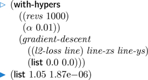

We have gotten the same result from frame 90:49, and we have cleanly separated out our hyperparameters.

The definitions of *gradient-descent* and *l2-loss* in frame 5 take functions as arguments and are not tied to a particular target function (like *line*).

<sup>7</sup>

This means that we can use these two functions for learning the *θ* for *arbitrary* target functions.

That is liberating!

Here is a new data set

(**define** *quad-xs*

[*−*1.0 0.0 1.0 2.0 3.0])

(**define** *quad-ys*

[2.55 2.1 4.35 10.2 18.25])

Draw its corresponding graph.

<sup>8</sup>

These points are not on a line

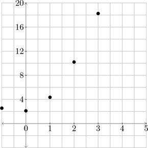

Indeed, they are not. So, we must learn the *θ* of a different target function.

For this example, we use a simple *nonlinear* function.

<sup>9</sup>

What is a nonlinear function?

A nonlinear function is not *linear* in its arguments.

<sup>10</sup>

And …

A linear function is one that uses only addition and *scaling* to find its result.

<sup>11</sup>

What is scaling?

Scaling multiplies its argument by a fixed value or by a parameter. For example

(* 5.0 *x*)

scales the value of *x* by 5.0.

And if we have a parameter

*θ*<sub>0</sub>

then

(* *θ*<sub>0</sub> *x*)

scales the value of *x* by *θ*<sub>0</sub>.

<sup>12</sup>

So, this is why *line* is a linear function. It scales its argument *x* with *θ*<sub>0</sub> and adds *θ*<sub>1</sub> to it.

What nonlinear function does the data set in frame 8 represent?

A very good question.

Let's make the assumption that this data set is *quadratic*.

<sup>13</sup>

What does *quadratic* mean?

It means that it can be predicted by a quadratic function.

<sup>14</sup>

What is a quadratic function?

Here is a general definition of a quadratic function†

(**define** *quad* •

(λ (*t*)

(λ (*θ*)

(+ (* *θ*<sub>0</sub> (*sqr t*))

(+ (* *θ*<sub>1</sub> *t*) *θ*<sub>2</sub>)))))

The function *quad* has three scalar parameters provided in a *θ*.

†This might look more familiar as the quadratic equation with *t* replaced by *x*

*ax*<sup>2</sup> + *bx* + *c* = 0

<sup>15</sup>

Could we see an example of how *quad* works?

Sure.

Let's take

*t* to be 3.0

and

*θ* to be (**list** 4.5 2.1 7.8)

Show a same-as chart for this example.

<sup>16</sup>

Here it is

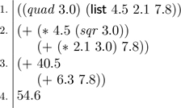

Does the use of *sqr* make *quad* nonlinear?

Indeed it does.

Now we use *gradient-descent* with *l2-loss* as the loss function to learn the *θ* for this data set with *quad* as the target function.

And what is the new expectant function from frame 63:24?

<sup>17</sup>

The expectant function is the loss function invoked on the target

(*l2-loss quad*)

And what is the objective function?

<sup>18</sup>

The objective function from frame 64:26 is the function obtained by invoking the expectant function on the new data set

((*l2-loss quad*) *quad-xs quad-ys*)

Great.

We invoke *gradient-descent* on this objective function and an initial *θ*.

What should this initial *θ* be?

<sup>19</sup>

Can we use 0.0's

(**list** 0.0 0.0 0.0)

as we did before?

Yes, we can.

Now let's consider the hyperparameters.

<sup>20</sup>

That's right.

We are now finding the *θ* for a different target function.

What scalars should we provide for the hyperparameters *revs* and *α*?

Since our target is a quadratic function that squares its argument, which here is *quad-xs*, it is likely that our gradients could get really large.

To avoid overshooting with large jumps between revisions, we guess a lower learning rate.

Experience tells us that 0.001 should be reasonable.

<sup>21</sup>

What about the scalar for *revs*?

For now, let's keep it at 1000, so our invocation of *gradient-descent* should be the body of the **with-hypers** in this revision chart

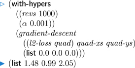

<sup>22</sup>

So, the result of *gradient-descent* with these hyperparameters and its target is

(**list** 1.48 0.99 2.05)

We have learned that the three values of the parameters for *quad* are 1.48, 0.99, and 2.05. This is similar to how we previously learned the values of *θ*<sub>0</sub> and *θ*<sub>1</sub> for *line*!

We have used *gradient-descent* with a target function other than *line*!

Indeed!

Now we let go of some more assumptions in how we use *gradient-descent* and *l2-loss*.

Here's a new data set

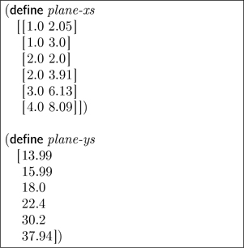

<sup>23</sup>

This data set is different since *plane-xs* is a tensor<sup>2</sup> made up of

6 2-element tensors<sup>1</sup>

whereas *plane-ys* is a tensor<sup>1</sup> made up of

6 scalars

Yes, that is correct.†

In the data sets

(*line-xs*, *line-ys*)

and

(*quad-xs*, *quad-ys*)

the *xs* and *ys* have always been tensors<sup>1</sup> of the same shape.

and

†Just as a line is a linear relationship between the two coordinates of a point in 2 dimensions, a plane is a linear relationship between the coordinates of a point in 3 dimensions.

<sup>24</sup>

How does this generalization impact *gradient-descent* and *l2-loss*?

Great question.

Here is a target function similar to *line*

(**define** plane •

(λ (*t*)

(λ (*θ*)

(+ (*•* *θ*<sub>0</sub> *t*) *θ*<sub>1</sub>))))

Here *t*, the argument to *plane*, is a tensor<sup>1</sup>. This is different from *line*, which expects a scalar instead.

<sup>25</sup>

And what is *•*†?

†Pronounced “dot product.”

Thanks, Josiah Willard Gibbs (1839–1903) and Edwin Bidwell Wilson (1879–1964).

The function *•*<sup>1</sup><sup>,</sup><sup>1</sup> is defined

(**define** •<sup>1,1</sup> •

(λ (*w t*)

(*sum*<sup>1</sup>

(* *w t*))))

where *w* and *t* are tensors of rank 1, and both must have the same shape.

<sup>26</sup>

Could we see an example of what it does?

Sure.

Here, for example, *•*<sup>1</sup><sup>,</sup><sup>1</sup> takes two tensors<sup>1</sup>

1. 1. (*•*<sup>1</sup><sup>,</sup><sup>1</sup> [2.0 1.0 7.0] [8.0 4.0 3.0])
2. 2. (*sum*<sup>1</sup>
3. (* [2.0 1.0 7.0] [8.0 4.0 3.0]))

Complete the same-as chart.

<sup>27</sup>

Here it is

1. 3. (*sum*<sup>1</sup>
2. [(* 2.0 8.0) (* 1.0 4.0) (* 7.0 3.0)])
3. 4. (*sum*<sup>1</sup>
4. [16.0 4.0 21.0])
5. 5. 41.0

We multiply the scalars pairwise yielding a new tensor<sup>1</sup> and then finally we produce the *sum* of the new tensor.

Using the *•*<sup>1</sup><sup>,</sup><sup>1</sup> function is a way of multiplying two tensors<sup>1</sup> and producing a single scalar.

We get the extended function • by extending this definition of •<sup>1</sup><sup>,</sup><sup>1</sup> to include tensors of rank higher than 1.

<sup>28</sup>

Okay.

The rank of the resulting tensor is then one lower than its arguments.

<sup>29</sup>

Isn't this because of the law from page 54?

## The Rule of Data Sets

In a data set (*xs*, *ys*)

both *xs* and *ys* must have the same number of elements.

The elements of *xs*, however, can have a different shape from the elements of *ys*.

| Indeed. Now we learn the well-fitted *θ* for *plane* from this data set using *l2-loss* and *gradient-descent* We begin by trying to find the initial estimate for *θ*. What should it be? | <sup>30</sup> | But to do that we need to know the shapes of *θ*<sub>0</sub> and *θ*<sub>1</sub> in frame 25. How do we find them? |
| --- | --- | --- |
| We determine them using the shape of the tensors from our data set (*plane-xs*, *plane-ys*) knowing that they will be used as arguments to *plane*. We know that each element in *plane-xs* is a tensor<… | <sup>31</sup> | Aha! So when we invoke *plane* on an element from *plane-xs*, a well fitted *θ* must produce a result that is the same shape as an element of *plane-ys*. |
| Correct. Since • behaves exactly like *sum*, and produces a result that is one rank lower than its arguments, in order to produce a scalar, its arguments must both be tensors<sup>1</sup> of the same l… | <sup>32</sup> | The first argument to *•* is *θ*<sub>0</sub> The second argument, in frame 26, is a tensor<sup>1</sup> from *plane-xs* So, the shape of *θ*<sub>0</sub> must be the same shape as a tensor<sup>1</sup> f… |
| Correct. And what about the shape of *θ*<sub>1</sub>? | <sup>33</sup> | The tensor *θ*<sub>1</sub> should have the same shape as the result of the function *plane* from frame 25, which must be the shape of every scalar drawn from *plane-ys* and so *θ*<sub>1</sub> must be … |
| Correct, again. Now determine the initial list of parameters *θ*, using shapes that are based on how they are used inside the target function, for example, in frames 25 and 26:25. | <sup>34</sup> | How about this (**list** [0.0 0.0] 0.0) where *θ*<sub>0</sub> is initialized to a tensor<sup>1</sup> [0.0 0.0] and *θ*<sub>1</sub> is initialized to the scalar 0.0 |

## The Rule of Parameters

(Final Version)

Every parameter is a tensor.

| Perfect. Here, *θ*<sub>0</sub> and *θ*<sub>1</sub> have different shapes. Because *θ* is a list, its members, unlike the elements of a tensor, can have different shapes. | <sup>35</sup> | Does having different shapes mean we have to rewrite some of our functions? |
| --- | --- | --- |
| No, not at all. | <sup>36</sup> | That's a relief. |

## The Rule of *θ*

*θ* is a list of parameters that can have different shapes.

We need just one more thing!

We need to decide what scalars to provide for hyperparameters *revs* and *α*.

For a first guess, let's keep the same scalars as for *quad* in frame 22.

<sup>37</sup>

Okay.

Now show the revision chart using **with-hypers** for the data set in frame 23.

<sup>38</sup>

Here it is

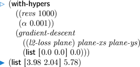

Excellent.

We have found the

well-fitted *θ*

<sup>39</sup>

How do we know it is the correct one?

We'll test it on one of the points from the data set given in frame 23.

Let's pick

*plane-xs|*<sub>3</sub>

1. 1. ((*plane* [2.0 3.91])
2. (**list** [3.98 2.04] 5.78))
3. 2. (+ (*•* [3.98 2.04] [2.0 3.91])
4. 5.78)
5. 3. 21.71

<sup>40</sup>

That's reasonably close to *plane-ys|*<sub>3</sub>, the given value 22.4.

Why aren't they exactly the same?

Because data sets are often noisy and target functions usually don't fit them exactly. A close enough match is typically all we can expect.

<sup>41</sup>

Now it's time for a break!

## Toys for Target Practice

*gradient-descent* (with hyperparameters *revs* and *α*) 99

(*quad-xs*, *quad-ys*) 100

*quad* 102

(*plane-xs*, *plane-ys*) 104

*plane* 105

• 106

**That was some heavy lifting!**

**Time for a *besan laddoo*** **!**

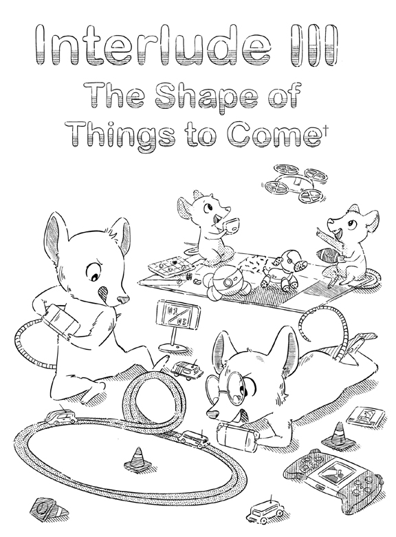

†Thanks, Herbert George Wells (1866–1946).

| Target practice is over. | <sup>1</sup> | Whew! At least we got to enjoy some *laddoos*. |
| --- | --- | --- |
| What is the shape of this tensor<sup>2</sup> [[2 4 5] [6 7 9]]? | <sup>2</sup> | It is (**list** 2 3) |
| Let's annotate this tensor<sup>2</sup> with its shape [[2 4 5] [6 7 9]]<sub>(2</sub> <sub>3)</sub> | <sup>3</sup> | That makes it a little easier to understand its shape. |
| We now drop the nested square brackets and write it† †We write tensors<sup>2</sup> the same way that matrices are normally written. Furthermore, we annotate the tensor with a shape. This is a less clu… | <sup>4</sup> | It appears that each inner tensor<sup>1</sup> is written as a separate row, without the enclosing brackets. |
| Yes, that is correct. An important instance of this is a tensor<sup>2</sup> where every row is a tensor<sup>1</sup> of exactly one scalar. | <sup>5</sup> | Could we see an example? |
| Here is a tensor<sup>2</sup> [[5] [7] [8]] which is written like this† †This is known as a *column matrix*. | <sup>6</sup> | So, we can understand the rank and shape of the tensor without counting brackets as in the law on page 35. How can we write the tensor<sup>2</sup> [[5 7 8]]? |
| Tricky question! The tensor<sup>2</sup> [[5 7 8]] has the shape (**list** 1 3) So we write it† [5 7 8]<sub>(1 3)</sub> †This is known as a *row matrix*. | <sup>7</sup> | This looks troublingly similar to [5 7 8] But that is a different tensor since its shape is (**list** 3) |
| Indeed [5 7 8] is a tensor<sup>1</sup> that has the shape (**list** 3) so we could have written it [5 7 8]<sub>(3)</sub> To keep things simple, however, we'll drop the shape annotation for all tensors… | <sup>8</sup> | So [5 7 8] is simply a tensor<sup>1</sup> with 3 scalars, whereas [5 7 8]<sub>(1 3)</sub> is a tensor<sup>2</sup> with 1 tensor<sup>1</sup>. |

**It's time for some apples!**

**Honey Crisp?**

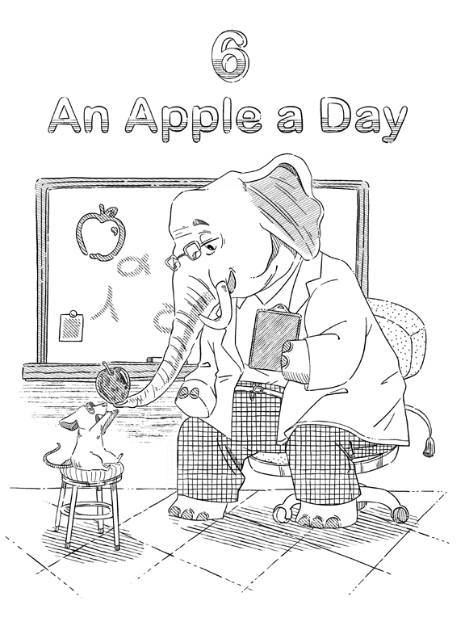

[output not shown]

## The Rule of Batches

We use the function *samples*. It takes two arguments. The first, *n*, is the number of points in the data set. The second, *s*, is the size of the sample set. Both are natural numbers greater than one, and *s* is less than or equal to *n*.

<sup>19</sup>

Why do we name the function *samples*?

That's because it picks a batch of indices in the same way that Maria picks random apples to taste.

<sup>20</sup>

Okay.

Invoking *samples* results in a list with *s* members, each being a randomly chosen index less than *n*. Here, we find a batch of 3 indices from a data set of length 20

(*samples* 20 3)

And here is an example of what it might return, since the indices are random

(**list** 18 2 11)

<sup>21</sup>

How is *samples* defined?

To define *samples*, we first need to learn how to randomly generate natural numbers for indices.

We do that using *random*, which accepts one argument, *n*, a positive natural number, and generates a randomly selected index from 0 to *n* − 1. For example

(*random*† 45)

might produce

31

or any other index from 0 to 44.

†Every time *random* is invoked, it probably generates a different random natural number from its previous invocation.

<sup>22</sup>

Okay.

How do we use *random* to generate a list of indices?

Here is a skeleton for *samples*

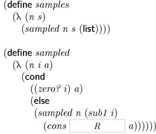

Here we use the support function *sampled*, where we are counting down from *s* to 0, and at each step we accumulate a randomly generated index.

Find *R*.

<sup>23</sup>

Since we are accumulating randomly generated indices, *R* must be

(*random n*)

Great.

This is the final version of *samples*

(**define** *samples* •

(λ (*n s*)

(*sampled n s* (**list**))))

(**define** *sampled*

(λ (*n i a*)

(**cond**

((*zero? i*) *a*)

(**else**

(*sampled n* (*sub1 i*)

(*cons* (*random n*) *a*))))))

Does *sampled* meet the requirements of simple accumulator passing on page 43?

<sup>24</sup>

Indeed it does.

The invocation of *sampled* is not wrapped, so we need look at only the formals of *sampled*

*n* does not change

*i* changes towards passing a base test

and

*a* accumulates a result†

†Since each number in *a* is chosen randomly, their order in the batch of indices does not matter.

Perfect.

Since *samples* picks indices randomly, does

(*samples* 20 3)

give the same answer at each revision?

<sup>25</sup>

It shouldn't.

That's correct, most of the time.†

At each revision, *samples* results in a new batch of indices. So, provided the size of the data set *n* is large enough, the chances of it producing the same *s* indices at every revision are very small.

†A single invocation of *samples* might also have repeated indices since each index is picked independently of the others.

<sup>26</sup>

So, now that we know how to randomly sample indices, how do we use these indices to get a batch from the data set?

We need a new toy for this!

Once again, *t*|*<sub>i</sub>* selects the ith element from a tensor *t* where *i* is the index.

Now we show how to select more than one element from the tensor *t*. Here, the elements to select are given by a batch *b*, of indices. We pick these elements from *t*

*t||<sub>b</sub>*

This results in a tensor of the same rank as *t*, but containing only those elements in *t* that correspond to the batch *b* of indices.

<sup>27</sup>

Could we see an example?

Sure.

Let's take *t* to be a tensor<sup>1</sup> with 7 elements

[5.0 2.8 4.2 2.3 7.4 1.7 8.1]

Here is a list *b* of 4 indices

(**list** 6 0 3 1)

<sup>28</sup>

How do we use this list of indices?

This way

1. 1. *t*||*<sub>b</sub>*
2. 2. [5.0 2.8 4.2 2.3 7.4 1.7 8.1]||<sub>(**list** 6 0 3 1)</sub>
3. 3. [8.1 5.0 2.3 2.8]

<sup>29</sup>

Can *t* have a rank higher than 1?

Yes, *t*'s rank can be higher than 1.

Here's an example where *t* is a tensor<sup>2</sup>, and *b* is the list from the previous example

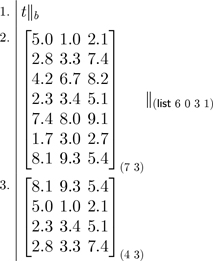

<sup>30</sup>

This looks like a useful toy.

Are we now ready to define the support function we suggested in frame 16?

We are, indeed!

Here is a skeleton of a function

*sampling-obj* that takes three arguments. The first, *expectant*, is an expectant function and the other two, *xs* and *ys*, form a data set

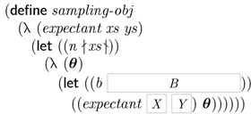

<sup>31</sup>

This function seems to be returning another function

(λ (*θ*) *…*)

Correct.

It returns an objective function that samples the data set instead of using the entire data set.

Find the expressions for *B*, *X*, and *Y*.

<sup>32</sup>

In this skeleton, *b* should be a batch of indices (which is a list), and *X* and *Y* must correspond to the samples extracted from the data set using those indices.

So, *B* should result in a list of sampled indices. But we're missing some information.

How large should our batch of indices be?

A very good question.

The batch size usually varies depending upon the data set and the kind of target function we are dealing with.

<sup>33</sup>

So should we just declare it as a hyperparameter?

Yes

(**declare-hyper** *batch-size*) •

Now, what is *B* in frame 31?

<sup>34</sup>

*B* should generate a batch of indices using

*samples*

with the number of points we have in the data set

as the first argument, and

*batch-size*

(*samples n batch-size*)

Perfect.

What about *X* and *Y* ?

<sup>35</sup>

Those expressions should use *b* to select the corresponding tensor from the formals *xs* and *ys*.

So *X* should be

*xs||<sub>b</sub>*

and Y should be

*ys||<sub>b</sub>*

Correct.

Here's *sampling-obj*

(**define** *sampling-obj* •

(λ (*expectant xs ys*)

(λ (*θ*)

(**let** ((*b* (*samples n batch-size*)))

((*expectant xs*||*<sub>b</sub> ys*||*<sub>b</sub>*) *θ*))))))

<sup>36</sup>

How do we use *sampling-obj*?

When we invoke *gradient-descent*, we now give it a *sampling-obj*.

For example

(**with-hypers**

((*revs* 1000)

(*α* 0.01)

(*batch-size* 4))

(*gradient-descent*

(*sampling-obj*

(*l2-loss line*) *line-xs line-ys*)

(**list** 0.0 0.0)))

Here our new hyperparameter *batch-size* is given the scalar 4.

<sup>37</sup>

This means that at each revision, we use only a batch of size 4 from the data set to measure the loss. So, we examine a mere

(* 4 1000)

points in total, instead of running through the entire data set at each revision.

And even if our data set has billions of points, each revision looks at only 4, right?

100% correct!

At each revision a new batch with only *batch-size* points is selected.

This kind of gradient descent where the objective function uses sampling is known as

*stochastic gradient descent*

<sup>38</sup>

What does *stochastic* mean?

## The Law of Batch Sizes

Each revision in stochastic gradient descent uses only a batch of size *batch-size* from the data set and the ranks of the tensors in the batch are the same as the ranks of the tensors in the data set.

An excellent question.

*Stochastic* is another way of saying we use random numbers to determine our results. Using *samples* as part of our objective function is what makes it stochastic.

<sup>39</sup>

Does stochastic gradient descent work for different targets?

It does! Let's return to our example from frame 105:25 using *plane* as our target function.

What does our expectant function look like?

<sup>40</sup>

Since our target function is *plane*, the expectant function must be

(*l2-loss plane*)

Correct.

Let us take

*revs* to be 15000

*α* to be 0.001

and

*batch-size* to be 4

<sup>41</sup>

Then our hyperparameters should look like

(**with-hypers**

((*revs* 15000)

(*α* 0.001)

(*batch-size* 4))

*…*)

From frame 108:34, the initial *θ* is

(**list** [0.0 0.0] 0.0)

How is *gradient-descent* invoked?

<sup>42</sup>

Using this revision chart

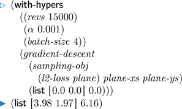

Great. That's enough for now.

<sup>43</sup>

Good! A break would be wonderful.

## Random Toys

*samples* 123

*t*||*<sub>b</sub>* 124

*batch-size* 126

*sampling-obj* 127

**Go have a slice of apple pie!**

**Preferably à la mode!**

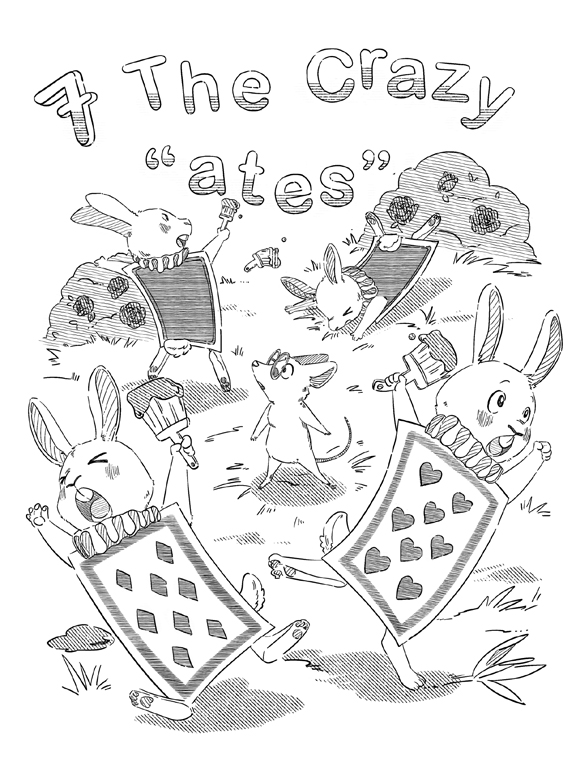

| How was the pie? | <sup>1</sup> | Warm and smothered with a dollop of vanilla ice cream. |
| --- | --- | --- |
| Mmm. Delicious. Here we teach our new toy *gradient-descent* some new tricks. | <sup>2</sup> | What kinds of tricks? |
| Tricks that make it more flexible, so we can change its behavior. | <sup>3</sup> | Why would we want to change its behavior? |
| So that it gets to its well-fitted *θ* with fewer revisions (i.e., a smaller value for *revs*). | <sup>4</sup> | That's a good reason. So how do we make it more flexible? |
| One of the reasons why *gradient-descent* from frame 99:5 is unable to get to its well-fitted *θ* with fewer revisions is because it has very little information to work from. | <sup>5</sup> | What other information does it need? |
| Before we get to the details of that, what matters here is that we must find a way to hold this information and bring it up to date as the parameter is revised. The first thing to remember is that thi… | <sup>6</sup> | Okay. |
| We start with our most recent and still dashed *gradient-descent* (**define** *gradient-descent* (λ (*obj* *θ*) (**let** ((*f* (λ (Θ) (*map* (λ (*p g*) (*− p* (* *α g*))) Θ (∇ *obj* Θ))))) (*revise f … | <sup>7</sup> | Are we finally going to reveal how Θ meets our gr**ate** expectations from frame 90:48? |
| Indeed, this is the ultimate moment! What does *map* do in this function? | <sup>8</sup> | It invokes this function (λ (*p g*) (*− p* (* *α g*))) on every member of Θ and (∇ *obj* Θ) in a pairwise fashion. |
| Correct. In this dashed *gradient-descent*, we use *revise* to repeatedly revise a *list of parameters*. Much like *map*, the function *revise* is a general-purpose function. We can use it to revise a… | <sup>9</sup> | Could we see an example revising a different kind of value? |

## The Law of Revisions

As long as we make sure that *gradient-descent* accepts an initial *θ* and results in a well-fitted *θ*, any reasonable way of revising it from the first to the last revision is okay.

Sure, here is a mostly useless example but it serves to illustrate a trick for transforming our parameters by first wrapping them up and then unwrapping them later.†

What is the value of this expression?

(*map* (λ (*p*)

(**list** *p*))

*θ*)

†This use of the terms wrapp*ing* (*ed* ) and unwrapp*ing* (*ed* ) for parameters is different from their use describing recursive definitions in chapter 2.

<sup>10</sup>

It wraps each parameter *p* in *θ* into a singleton‡ and therefore produces a list of singletons.

‡A list with one member.

Yes.

Whenever a parameter is wrapped in a list, we refer to it as

*an accompanied parameter*†

†From 1964, *The Miles Davis Quintet* would have been *The Miles Davis Singleton* were it not for his accompaniments of

Tony Williams (1945–1997).

Wayne Shorter (1933–),

Ron Carter (1937–), and

Herbie Hancock (1940–),

Its parameter, however, would have been Miles Davis (1926–1991).

Thanks to all.

<sup>11</sup>

But here nothing is accompanying the parameter in this list, correct?

That's correct. The parameter is keeping itself company.

This is our *lonely representation*.†

Θ is a list of accompanied parameters, but in this lonely representation, there are no accompaniments.

<sup>12</sup>

How do we use this lonely representation?

†The lonely representation simply shows an example where the list has no accompaniments. We'll be adding information to accompany parameters to get more meaningful representations.

We are going to use it for revisions within *gradient-descent*.

But first, we make sure we can convert back and forth between Θ and *θ*. So we need two support functions. Here's the first one. It takes a *θ* and converts it to a Θ.

We refer to it as *lonely-i*, with *i* for

*infl*ate

(**define** *lonely-i*

(λ (*θ*)

(*map* (λ (*p*)

(**list** *p*))

*θ*)))

Explain *lonely-i*.

<sup>13</sup>

It takes a *θ* and it wraps each parameter in *θ* in a list, giving us a Θ.

Correct.

Now define *lonely-d*, with *d* for *defl*ate, that does the opposite. It takes a Θ and results in a *θ*.

<sup>14</sup>

So, we can *map* over Θ and pick the *revised* parameter out of each accompanied parameter

(**define** *lonely-d*

(λ (Θ)

(*map* (λ (*p*)

*p*<sub>0</sub>)

Θ)))

Here *p* is an accompanied parameter, correct?

Yes.

<sup>15</sup>

<sup>16</sup>

Oh! It's pretty obvious now!

Since we are now revising Θ and not *θ*, we define a function that does the revision for us

(**define** *lonely-u*

(λ (Θ *gs*)

(*map* (λ (*p g*)

(**list** (*− p*<sub>0</sub> (* *α g*))))

Θ

*gs*)))

The *u* in *lonely-u* stands for *upd*ate, because this function is an instance of what are referred to as *update functions*.

Explain *lonely-u*.

<sup>17</sup>

This function maps over Θ and the gradients *gs* in a pairwise fashion. Since each member of Θ is a singleton, we extract the parameter from the accompanied parameter and use the gradient and the learning rate to produce the revised parameter.

But why does it wrap the result in a list?

That's because *lonely-u* must result in a revised Θ rather than a revised *θ*.

<sup>18</sup>

Ah!

Wrapping the result in a list ensures that the well-fitted Θ is still a list of singletons.

We use these three functions

*lonely-i*

*lonely-d*

and

*lonely-u*

to generalize *gradient-descent*.

<sup>19</sup>

How can we do that?

Rather than scattering the three “ates” throughout the *gradient-descent*, we pass them to a more general *gradient-descent*

(**define** *gradient-descent*

(λ (*in**flat**e de**flat**e upd**ate*)

(λ (*obj* *θ*)

*…*)))

Now define *lonely-gradient-descent* using this new

*gradient-descent*

<sup>20</sup>

Here it is!

(**define** *lonely-gradient-descent*

(*gradient-descent*

*lonely-i lonely-d lonely-u*))

And we see that those “ates” rhyme!

Interesting, right.

Let's now use this more general skeleton of *gradient-descent*

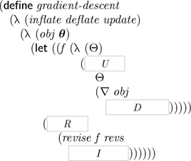

Find *I*, *D*, *U*, and *R*.

<sup>21</sup>

Since we are revising a list of singletons, that means we must invoke *revise* with an initial Θ. So, *I* must be

(*inflate* *θ*)

*D* is the second argument to ∇, so it has to be a list of parameters. This means we must convert the Θ back to a *θ*. So, *D* must be

(*deflate* Θ)

*U* must be invoked to update Θ, so *U* must be

*update*

Finally, *gradient-descent* must result in a *θ*. The invocation of *revise*, however, results in a Θ. So when we're done, we must convert the well-fitted Θ back to the well-fitted *θ*. So *R* must be

*deflate*

Excellent.

Here is our penultimate *gradient-descent*

(**define** *gradient-descent*

(λ (*inflate deflate update*)

(λ (*obj* *θ*)

(**let** ((*f* (λ (Θ)

(*update*

Θ

(∇ *obj*

(*deflate* Θ))))))

(*deflate*

(*revise f revs*

(*inflate* *θ*)))))))

<sup>22</sup>

And it is still dashed!

Yes, it is.

But we should test it before we go ahead. And we're going to do this a lot with different values of *inflate*, *deflate*, and *update*, so let's make things a little easier for ourselves.

Define a function *try-plane* that takes a function argument *a-gradient-descent*, which can be invoked within the **with-hypers**-expression in frame 129:42.

<sup>23</sup>

Here is this new dashed definition

(**define** *try-plane*

(λ (*a-gradient-descent*)

(**with-hypers**

((*revs* 15000)

(*α* 0.001)

(*batch-size* 4))

(*a-gradient-descent*

(*sampling-obj*

(*l2-loss plane*) *plane-xs plane-ys*)

(**list** [0.0 0.0] 0.0)))))

We use *try-plane* with a specific gradient-descent function, for example

*lonely-gradient-descent*

<sup>24</sup>

This definition is very convenient!

It is perfect!

<sup>25</sup>

It is a useful function to try the same test repeatedly.

Let's look at another representation, where Θ is identical to *θ*. We refer to this as the *naked* representation.

Here, *p*, which must be deflated, and *p*, which is inflated, are identical.

Define the *inflate* function.

<sup>26</sup>

Even though *θ* is identical to Θ, we should stick with the pattern, so *naked-i* maps the identity function over *θ*

(**define** *naked-i*

(λ (*θ*)

(*map* (λ (*p*)

(**let** ((*p p*))

*p*))

*θ*)))

Similarly, *naked-d* takes a *p*, which must be inflated, and yields a deflated *p* that is identical.

Now define the *deflate* function for this representation.

<sup>27</sup>

Using the same pattern we have

(**define** *naked-d*

(λ (Θ)

(*map* (λ (*p*)

(**let** ((*p p*))

*p*))

Θ)))

Exactly!

Knowing that *θ* and Θ are the same, define *naked-u*.

<sup>28</sup>

*θ* and Θ are the same, so here is *naked-u*

(**define** *naked-u*

(λ (Θ *gs*)

(*map* (λ (*p g*)

(*− p* (* *α g*)))

Θ

*gs*)))

Couldn't we have used *p*<sub>0</sub> instead of *p*?

No, using *p*<sub>0</sub> would have assumed that *p* is accompanied.

<sup>29</sup>

So, *p* is not accompanied because *naked-i* merely maps the identity function.

Now define *naked-gradient-descent*.

<sup>30</sup>

Here it is

(**define** *naked-gradient-descent*

(*gradient-descent*

*naked-i naked-d naked-u*))

Excellent.

Rewrite the example from frame 24, this time using the naked representation.

<sup>31</sup>

But the definitions for the lonely and naked representations are still dashed!

They are. We're going to simplify them.

To do that, let's consider something

crazy

Each definition of *inflate* and *deflate*, respectively, looks like this!

(**define** *inflate*

(λ (*θ*)

(*map* (λ (*p*)

*…*)

*θ*)))

(**define** *deflate*

(λ (Θ)

(*map* (λ (*p*)

*…*)

Θ)))

And what about *update*?

<sup>32</sup>

Here it is

(**define** *update*

(λ (Θ *gs*)

(*map* (λ (*p g*)

*…*)

Θ

*gs*)))

Why does this matter?

Great question!

And here's what's crazy about the “ates” from frame 20. If we make a consistent change to the dashed *gradient-descent*, we can simplify each of these definitions.

<sup>33</sup>

How is that possible?

Observe that we pass arguments into each “ate” function and then invoke *map* over them.

<sup>34</sup>

That is true.

We can use this observation to move the *map*s about so our “ates” can be simplified.

Any thoughts lurking about?

<sup>35</sup>

Nothing at all.

Let's take *inflate*.

Our current *gradient-descent* invokes *inflate* on *θ* like this

(*inflate* *θ*)

Since the *inflate* functions we have seen so far rely on knowing that *θ* is a list and each of them maps some λ-expression over this list, we can rewrite this invocation of inflate temporarily like this

(*map* (λ (*p*) …) *θ*)

<sup>36</sup>

Oh, so regardless of what kind of *inflate* function we encounter, it always starts with invoking *map*.

Correct!

So, we can simplify *inflate* functions by moving the *map* to *gradient-descent*, and letting the *inflate* be simply the λ-expression.

<sup>37</sup>

Shouldn't that also work for the

*deflate*

and the

*update*?

Yes, and here's the crazy answer.

For uses of an “ate” in *gradient-descent*

(*ate* *θ*) becomes (*map ate* *θ*)

(*ate* Θ) becomes (*map ate* Θ)

and

(*ate* Θ *gs*) becomes (*map ate* Θ *gs*)

Refine the dashed *gradient-descent* one last time, but this time, the crazy way to get the final *gradient-descent*.

<sup>38</sup>

Here is the ultim**ate** *gradient-descent*

(**define** *gradient-descent* •

(λ (*inflate deflate update*)

(λ (*obj θ*)

(**let** ((*f* (λ (Θ)

(*map update*

Θ

(∇ *obj*

(*map deflate* Θ))))))

(*map deflate*

(*revise f revs*

(*map inflate θ*)))))))

With this final *gradient-descent*, we must remove the *map*s from the definition of each “ate”.

Let us start with *lonely-i* in frame 13

(**define** *lonely-i*

(λ (*θ*)

(*map* (λ (*p*)

(**list** *p*))

*θ*)))

How should we refine this to go with our final *gradient-descent*?

<sup>39</sup>

Since *gradient-descent* is now responsible for mapping the inflate function over *θ*, *lonely-i* should be this

(**define** *lonely-i*

(λ (*p*)

(**list** *p*)))

And what about *lonely-d* and *lonely-u*?

<sup>40</sup>

Here they are

(**define** *lonely-d*

(λ (*p*)

*p*<sub>0</sub>))

(**define** *lonely-u*

(λ (*p g*)

(**list** (*− p*<sub>0</sub> (* *α g*)))))

## The Law of the Crazy “ates”

For any representation, the three “ates” are concerned with only one parameter and its accompaniments, and are not directly concerned with either *θ* or Θ.

[output not shown]

## Crazy Toys

*gradient-descent* 140

*naked-gradient-descent* 143

**How about a properly inflated souffié?**

**We want to deflate it** *tout de suite***!**

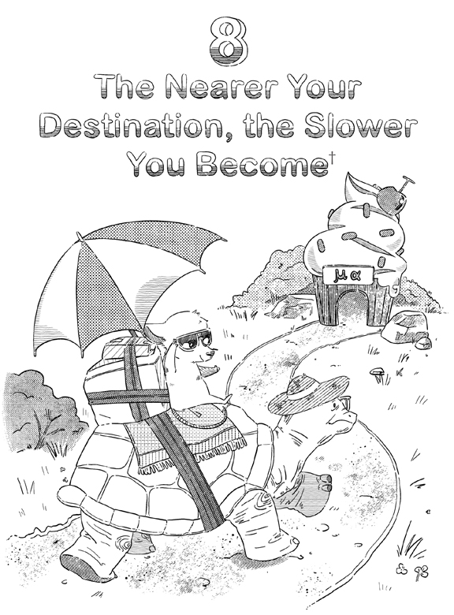

†With apologies and thanks, Paul Frederic Simon.

Was the souffié delicious?

<sup>1</sup>

We “ate” it and it was gr**ate**!

Here we learn some new tricks with our new toy, the crazy

*gradient-descent*

<sup>2</sup>

What kinds of tricks?

We'll learn tricks to make us reach the well-fitted *θ* with fewer revisions.

<sup>3</sup>

That sounds promising!

Should we begin?

We are off to the races!

Relay races, to be precise.

<sup>4</sup>

Intriguing.

What about relay races?

Groucho is training a relay team with Chico, Harpo, Gummo, and Zeppo.†

†Thanks Marx Brothers:

Leonard Joseph “Chico” (1887–1961),

Arthur “Harpo” (1888–1964),

Julius Henry “Groucho” (1890–1977),

Milton “Gummo” (1892–1977),

and Herbert Manfred “Zeppo” (1901–1979).

<sup>5</sup>

That's one funny team.

Indeed.

Chico is many times faster than Harpo, who is many times faster than Gummo, who is many times faster than Zeppo.

They run in that order; each person runs around the track once and passes the baton on to the next.

<sup>6</sup>

Zeppo must be a really slow runner.

Yes.

For the team to be well-prepared, Groucho must get the slower runners to run faster.

<sup>7</sup>

That seems like quite a challenge.

Groucho has come up with a clever, perhaps unscrupulous, coaching strategy.

Instead of letting go of the baton when passing it to Harpo, Chico holds on to the baton awhile as Harpo grabs it. This forces Harpo to try to run as fast as Chico for as long as they're both holding on to the baton.

Chico drags Harpo along with him for part of the track, making Harpo's velocity much higher.

<sup>8</sup>

Ah!

Harpo absorbs a little bit of Chico's velocity.

Correct.

And then Harpo does the same to Gummo.

<sup>9</sup>

Gummo absorbs a little bit of Harpo's velocity.

And also some from Chico!

<sup>10</sup>

Oh yes.

Because Harpo has a little bit of Chico's velocity.

Does Gummo do the same to Zeppo?

Yes, he does.

<sup>11</sup>

Now the slow runners are all faster because the faster runners that came before have transferred some of their speed to them.

Yes.

Groucho has managed to raise the slower velocities by spreading the velocities across the runners.

They can now complete their race much faster.

<sup>12</sup>

How does this relate to *gradient-descent*?

Here, again, is the function *naked-u* from frame 142:42

(**define** *naked-u*

(λ (*p g*)

(*− p* (* *α g*))))

<sup>13</sup>

Yes.

It's the update part of the naked representation for *gradient-descent*.

Explain how this function updates parameters.

<sup>14</sup>

This function multiplies the gradient *g* by the learning rate *α*, and subtracts the result from the parameter *P* to yield the next *P*, so that ultimately we get closer to a well-fitted *θ*.

Correct.

Recall the loss graph from frame 77:13.

<sup>15</sup>

Yes, the one that had the two tangents in it.

The very same.

What do we know about each tangent as it approaches the lowest point on the graph?

<sup>16</sup>

Each tangent gets less steep as it approaches the bottom of the curve.

Indeed.

The slope of the tangent, (i.e., the gradient) gets smaller. In fact, as the curve's bottom is approached, the gradient gets closer and closer to 0.0. Furthermore, at the very bottom of the curve, the gradient is exactly 0.0.

What happens when we multiply a really small gradient with a really small learning rate as we do

(* *α g*)

in update functions?

<sup>17</sup>

Oh, we get something even smaller!

So, at each revision closer to the bottom, the amount of change to each parameter gets smaller and smaller, correct?

Yes, it does.

The change that we make to a given parameter at each revision is known as the *velocity* of descent.

So what can we say about the velocity of descent as it approaches the bottom of the curve?

<sup>18</sup>

The velocity slows down!

Wait a minute! That's exactly like our relay racing team!

And we can speed up the whole process by using Groucho's clever strategy!

<sup>19</sup>

How do we do that?

Here, once more, is *naked-u* from frame 142:42

(**define** *naked-u*

(λ (*p g*)

(*− p* (* *α g*))))

What is the velocity in this λ-expression?

<sup>20</sup>

Since we subtract (* *α g*), the change to *p*, (i.e., the velocity) is

(− (* *α g*))

Correct.

Groucho's strategy implies that we should boost our velocity by adding some fraction *μ* of the velocity *v*, of the *previous* revision, to the change we expect to make in the *current* revision.

<sup>21</sup>

What does this mean for our velocity?

Our new velocity expression then becomes

(+ (* *μ v*) (*−* (* *α g*)))

which is better written

(*−* (* *μ v*) (* *α g*))

<sup>22</sup>

Is *μ* a hyperparameter?

It is.

We declare it

(**declare-hyper** *μ*) •

The hyperparameter *μ* is between 0.0 and 1.0 and represents the decimal fraction of the previous velocity we want to retain for the next velocity.†

†The recommended scalar for *μ* is usually about 0.9.

<sup>23</sup>

Where does *v* come from?

Here, *v* represents the velocity of the most recent revision (i.e., the speed of the runner handing off the baton).

<sup>24</sup>

Is the velocity an accompaniment of its corresponding parameter?

Yes, it is.

What can we say about the shape of *v*?

<sup>25</sup>

Since *v* is the change that is made to its parameter, it should have the same shape as its parameter.

Correct!

Here is *velocity-i*, the *inflate* function

(**define** *velocity-i*

(λ (*p*)

(**list** *p* (*zeroes p*))))

The function *velocity-i* adds an initial accompaniment to the parameter *p*.

<sup>26</sup>

What is *zeroes*?

The function *zeroes* produces a tensor with the same shape as its argument, but made up entirely of 0.0s.

Now explain how the function *velocity-i* works.

<sup>27</sup>

It produces a zeroed tensor in the shape of *p*.

Why do we let the velocity be a zeroed tensor?

That's because at the first revision, there really hasn't been any change to any parameter†. So using a zeroed tensor is a reasonable choice for the initial velocity.

†Following from the law on page 142, we can stop thinking about *θ* and Θ and focus only on parameters.

<sup>28</sup>

Okay.

Now define the corresponding deflate function *velocity-d*.

<sup>29</sup>

This deflate function should result in the parameter, which is at index 0 in the inflated representation

(**define** *velocity-d*

(λ (*p*)

*p*<sub>0</sub>))

Excellent.

We can now define *velocity-u*. It expects an accompanied parameter *P* where the parameter *P*0 is accompanied by its velocity *P*1 from the last revision. As with all update functions, the gradient *g* is its second argument.

<sup>30</sup>

We give the name *v* to the expression *V*. The body of the **let**-expression is the updated accompanied parameter, which is returned from the function. The accompaniment there is *v*. Therefore, *V* must be the velocity, which is the change we must make to *p*<sub>0</sub>.

From frame 22, this velocity is

(*−* (* *μ P*<sub>1</sub>) (* *α g*))

Correct.

Here is *velocity-u*

(**define** *velocity-u*

(λ (*p g*)

(**let** ((*v* (− (* *μ p*<sub>1</sub>) (* *α g*))))

(**list** (+ *p*<sub>0</sub> *v*) *v*))))

Now define *velocity-gradient-descent*.

<sup>31</sup>

Sure, we provide *velocity-i*, *velocity-d*, and *velocity-u* to *gradient-descent*

(**define** *velocity-gradient-descent* •

(*gradient-descent*

*velocity-i velocity-d velocity-u*))

We now make *try-plane* more general, but still dashed, by adding an additional argument, *a-revs*. This allows us to more easily experiment with different scalars for the *revs* hyperparameter

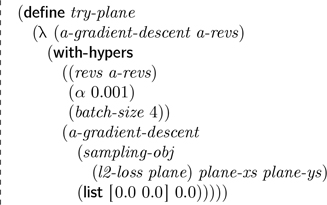

<sup>32</sup>

Wow.

Is this form of gradient descent known as

*velocity* gradient descent?

Actually, no.

It is known as

*momentum* gradient descent†

†Thanks, David Everett Rumelhart (1942–2011), Geoffrey Everest Hinton (1947–), and Ronald James Williams (1944–).

<sup>33</sup>

That's an odd name.

Why *momentum*?

Good question.

That's because we multiply the velocity *v* by a constant *μ*. The resulting expression is analogous to the formula of momentum in physics.†

†**p** = *m***v**, where **p** is the momentum, *m* is the mass of an object, and **v** is its velocity.

<sup>34</sup>

Are there other ways to improve the velocity of descent?

Yes, there are, but that's for the next interlude!

Remember to transfer some velocity from this chapter to the interlude.

<sup>35</sup>

But what about a snack?

## Fast Toys

*μ* 149

*velocity-gradient-descent* 151

**How about a slice of date-and-pecan pie?**

**It is Groucho's favorite!**

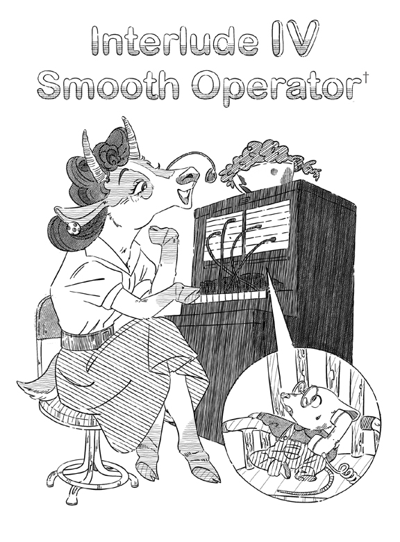

†Thanks, Lily Tomlin (1939–) for Ernestine and Edith Ann; and *Sade*: Sade Adu (1959–), Dave Early (1957–1996), Paul Spencer Dunman (1957–), Stuart Colin Matthewman (1960–), and Andrew Hale (1962–).

Groucho's “date-and-pecan pie”?†

†Thanks, Rosemary Wilson (1910–1986) and Ruth Pool (1934–).

<sup>1</sup>

Now we know why it is Groucho's favorite dessert!

Good.

Before we look at other update algorithms, we must understand

*smoothing*

<sup>2</sup>

What is smoothing?

Here is a function *smooth*

(**define** *smooth* •

(λ (*decay-rate average g*)

(+ (* *decay-rate average*)

(* (*−* 1.0 *decay-rate*) *g*))))

where *decay-rate* must always be a scalar between 0.0 and 1.0, *average* is a historically-accumulated average†, and *g* is a gradient. Both *average* and *g* must be tensors of the same shape.

What does *smooth* do?

†Shortened to “historical average.”

<sup>3</sup>

Since *decay-rate* is a scalar between 0.0 and 1.0, it seems to be blending two tensors using

*decay-rate*

and

(*−* 1.0 *decay-rate*)

as weights.

That's correct.

Let's see an extended example of how it is used over time. Here are seven scalars

50.3 22.7 4.3 2.7 1.8 2.2 0.6

Find

(*smooth* 0.9 0.0 50.3)

<sup>4</sup>

The result of this *smooth* invocation is the scalar 5.03

1. 1. (*smooth* 0.9 0.0 50.3)
2. 2. (+ (* 0.9 0.0) (* 0.1 50.3))
3. 3. (+ 0.0 5.03)
4. 4. 5.03

Correct.

Now, how about this?

(*smooth* 0.9 5.03 22.7)

<sup>5</sup>

We are blending the scalar 5.03 with the next scalar 22.7 in our sequence.

Here is the same-as chart

1. 1. (*smooth* 0.9 5.03 22.7)
2. 2. (+ (* 0.9 5.03) (* 0.1 22.7))
3. 3. (+ 4.53 2.27)
4. 4. 6.8

That is right.

Let's repeat this one more time.

Find

(*smooth* 0.9 6.8 4.3)

<sup>6</sup>

Here goes

1. 1. (*smooth* 0.9 6.8 4.3)
2. 2. (+ (* 0.9 6.8) (* 0.1 4.3))
3. 3. 6.55

Excellent.

Here are the original seven scalars from frame 4

50.3 22.7 4.3 2.7 1.8 2.2 0.6

Compare the *smooth*ed seven scalars to the original seven scalars.

†The underlined scalars are the results of the first three invocations of *smooth*, excluding the starting value of 0.0.

<sup>7</sup>

The *smooth*ed are much *smooth*er than the original scalars. In other words, the smoothed scalars don't vary as much as the original scalars and the variations between them are much gentler.

Yes, the seven scalars in the *smooth*ed historical averages are much closer to each other than the corresponding seven original scalars are to each other.

Repeatedly invoking *smooth* over these scalars “averages” out variations by blending historical scalars with newer ones.

What's the importance of 0.9 that we pass for *decay-rate*?

<sup>8</sup>

It means that in order to find the new historical average, we use only 90% of the prior historical average, and every new scalar encountered is diminished to 10% of its value. Thus new scalars that vary wildly from the historical average contribute only a small fraction to the new historical average.

Does *decay-rate* always have to be 0.9?

Oh no, that's just for this example.

In general, the *decay-rate* can be any number between 0.0 and 1.0.

<sup>9</sup>

Sure.

Now let's consider the first scalar 50.3. The first time we invoke *smooth*, we multiply it by 0.1 and get 5.03.

The next time we invoke *smooth*, this scalar is multiplied by 0.9. This means the contribution of the first scalar to the next *smooth*ed result (rounded to two decimal places) is

0.9 *×* 0.1 *×* 50.3 = 4.53

<sup>10</sup>

Aha!

It contributes less and less to the historical average as newer data are encountered.

Yes, it does.

We refer to *decay-rate* as the *rate of contribution.* The contribution of earlier items decays as more items are incorporated.

Find the formula for the contribution of the scalar 50.3 after *n* invocations of *smooth*.

<sup>11</sup>

After the *n*th invocation of *smooth*, the contribution is

0.9*<sup>n−</sup>*<sup>1</sup> *×* 0.1 *×* 50.3

Correct.

In general, this is true of any scalar encountered. The contribution of that scalar decays over time according to this formula.

<sup>12</sup>

So, *smooth* seems to be a way of incorporating historical information that is less relevant as we move forward.

Yes, but this is also true for tensors of any rank!

Since *smooth* is defined using extended functions, the arguments *average* and *g* can be tensors with compatible shapes. In most instances, the two have the same shape.

And if so, the smoothed result has the same shape as the arguments.

<sup>13</sup>

How about an example?

Suppose, after a time, we have a historical average of

[0.8 3.1 2.2]

and now we encounter the following three tensors

[1.0 1.1 3.0]

[13.4 18.2 41.4]

[1.1 0.3 67.3]

How should we blend in these new tensors into our historical average?

<sup>14</sup>

Using *smooth*, of course!

Should we use 0.9 as the decay-rate?

Good idea.

Let's start with the first tensor

1. 1. (*smooth* 0.9 [0.8 3.1 2.2] [1.0 1.1 3.0])
2. 2. (+ (* 0.9 [0.8 3.1 2.2])
3. (* 0.1 [1.0 1.1 3.0]))

Complete this same-as chart.

<sup>15</sup>

Here it is

1. 3. (+ [0.72 2.79 1.98] [0.1 0.11 0.3])
2. 4. [0.82 2.9 2.28]

Correct.

Blending this new historical average

[0.82 2.9 2.28]

with the second tensor<sup>1</sup>

[13.4 18.2 41.4]

we get

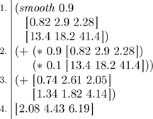

Now blend in the third tensor

[1.1 0.3 67.3]

<sup>16</sup>

Sure

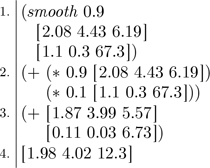

Very good.

Compare the original three tensors<sup>1</sup>

[1.0 1.1 3.0]

[13.4 18.2 41.4]

[1.1 0.3 67.3]

to the three *smooth*ed tensors<sup>1</sup>

[0.82 2.9 2.28]

[2.08 4.43 6.19]

[1.98 4.02 12.3]

<sup>17</sup>

It is as if we have smoothed the individual scalars corresponding to the elements of those tensors.

How do we use *smooth* with

*gradient-descent*?

That's a topic for the next chapter!

<sup>18</sup>

All right.

## Smooth Toys

*smooth* 155

**To break or not to break?**

**That is the question.**†

†With apologies to William Shakespeare (1564–1616).

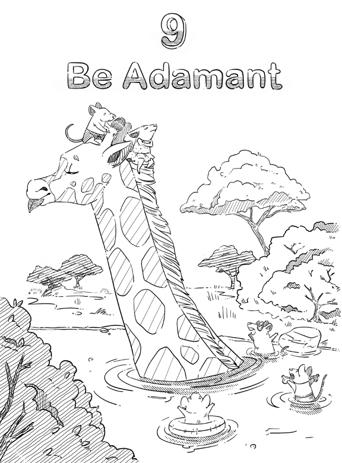

Onwards, then!

The velocity-based update algorithm from frame 149:21 improves the velocity of a revision by borrowing some velocity from the preceding revision.

<sup>1</sup>

That seems like a useful trick.

It is.

But there are other ways to improve the velocity of a revision. These algorithms work by modifying the fraction of the gradient used at each revision.

<sup>2</sup>

That's an interesting approach.

We know from frame 148:17 that the gradient approaches 0.0 as we roll down to the bottom of the incline.

What can we say about the velocity of the gradient?

<sup>3</sup>

Since our *α* so far has been a constant, we know that it causes the velocity of the gradient descent to slow down in a similar way.

Indeed.

Because *α* represents the fraction of the gradient we're going to use as our velocity, another approach to addressing this problem is to make this fraction *adaptive.*

<sup>4</sup>

What does adaptive mean?

Adaptive here means that the fraction is decided based on the gradient and its historical values.

<sup>5</sup>

Does that mean we revise *α* at every revision as well?

Good question.

Not directly. Instead, we multiply *α* with a factor *D* that reacts to the current gradient and its historical values.

<sup>6</sup>

How does *D* behave as our gradient slows down?

The fraction of the gradient we use as our velocity at every revision should reduce more slowly than the rate at which the gradient reduces.

<sup>7</sup>

This means that *D* must get larger as the gradient gets smaller, since *α* itself is constant.

Correct.

We say that *D* varies *inversely* as the gradient.

<sup>8</sup>

How do we find this mysterious *D*?

Here we refer to *G* as a *modifier*.

<sup>9</sup>

And now our task is to find *G*, which we know must depend on the gradient and its history.

Exactly.

<sup>10</sup>

Oh, so we must divide *α* by the modifier to change the fraction of the gradient we must use.

Correct.

How can we achieve this?

<sup>11</sup>

Could we simply say that *G* is the gradient itself? For example like in this update function where *g* is the gradient

(**define** *naked-u-with-divide*

(λ (*p g*)

(*− p* (* (*÷ α g*) *g*))))

No, we can't.

In other words, the effect of *g* would have been nullified.

<sup>12</sup>

Oh, right.

Then our velocity of descent would become the constant *α* and it would not depend upon the gradient, which would not be at all what we've intended.

We need something that takes the history of *g* into account but is not susceptible to all the variations in *g*, so that the effect of *g* is not nullified.

<sup>13</sup>

It sounds as if we could use our new toy *smooth* here!

Correct!

The solution is to use *smooth* to historically accumulate a modifier that is based on *g*.

<sup>14</sup>

Could we see this new update function?

Sure.

We need a representation with an accompaniment based on our smoothed gradients.

Like other update functions, *rms-u* takes an accompanied parameter and a gradient and revises the accompanied parameter. The accompaniment *P*<sub>1</sub> is the smoothed value derived from the gradient *g*.

Here *r* is the value we determine as the new accompaniment. It is part of the returned accompanied parameter. It also, however, is used inside *G*.

Find *R*.

<sup>15</sup>

*R* has to be an invocation of *smooth* because it has to be historically averaged.

We'll need a decay rate for it.

†*rms* is pronounced “*R-M-S*.”

For readers who may wish to do so, lexical scope allows for all the hats to be dropped, so to speak.

We will!

It is provided with a hyperparameter

(**declare-hyper** *β*) *•*

<sup>16</sup>

because *p*<sub>1</sub> is the historically averaged value.

Correct.

Now our task is to find *S*.

<sup>17</sup>

Isn't *S* just *g*?

Not quite.

The gradient *g* can be negative, and if we get too many consecutive negative gradients, then our historical averages can themselves become negative.

<sup>18</sup>

Why is becoming negative a problem?

When that happens, we end up *ascending* the gradient instead of descending it.

<sup>19</sup>

Does that mean we would move our *θ* in a direction that

*increases* the loss

instead of in a direction that

*decreases* the loss?

Yes, that is correct.

So, we should make sure *r* is always nonnegative.

We recognize this problem from frame 60:14, where we could have negative values but we needed them to be nonnegative.

<sup>20</sup>

Yes.

We fixed the problem by squaring the value.

Should *S* be (*sqr g*)?

Correct.

So this is what *R* looks like

(*smooth β p*<sub>1</sub> (*sqr g*))

Now let's move on to finding *G*.

<sup>21</sup>

Why isn't *G* just *r*?

Good question.

The problem with squares is that they grow much faster than the scalar that is being squared.

If we were to use *r* for *G*, the modified learning rate would increase at a faster rate than the rate at which the gradient reduces.

<sup>22</sup>

Why is that a problem?

From way back in frame 67:37, we know that this could cause the descent to overshoot the lowest point in the loss curve.

So, how do we modify *r* so that it tracks the gradient more closely, and not the square of the gradient?

<sup>23</sup>

Aha!

We can take its square root using the function *sqrt*.

Then, should *G* be this

(*sqrt r*)?

Yes, that is almost correct.

We need to account for the unlikely possibility that *r* would be 0.0.

<sup>24</sup>

Oh, that would cause the division of *α* to be undefined.

Correct.

This problem, however, is easily solved by adding a tiny constant *ϵ* known as the *stabilizer*, to (*sqrt r*).

<sup>25</sup>

What should *ϵ* be?

We define *ϵ*

(**define** *ϵ* 1e*−*08)

Now find *G*.

<sup>26</sup>

*G* must be

(+ (*sqrt r*) *ϵ*)

What does the final version of *rms-u* look like?

Here it is

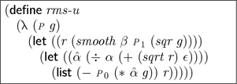

Let's now define *rms-gradient-descent*.

<sup>27</sup>

We need to first define the corresponding inflate and deflate functions, don't we?

Oops, thanks! Indeed we do.

They look similar to *velocity-i* from frame 150:26 and *velocity-d* from frame 151:29, since we set the initial value of each *r* accompaniment to a zeroed tensor of the same shape as the parameter.

Define *rms-i* and *rms-d*.

<sup>28</sup>

Here is *rms-i*. We accompany *p* with *r*, a zeroed tensor

(**define** *rms-i*

(λ (*p*)

(**list** *p* (*zeroes p*))))

Similarly, *rms-d* simply extracts the parameter *p* from the accompanied parameter

(**define** *rms-d*

(λ (*p*)

*p*<sub>0</sub>))

So *now* define

*rms-gradient-descent*

<sup>29</sup>

Here it is

(**define** *rms-gradient-descent* •

(*gradient-descent*

*rms-i rms-d rms-u*))

Could we see an example of its use?

We'll take the same example from frame 152:32. But first, we must determine each hyperparameter.

What should our learning rate be?

<sup>30</sup>

Since *rms-u* uses a continuously modified learning rate, should we start with a higher learning rate and expect it to be adapted as *rms-gradient-descent* proceeds?

Good guess.

Let's start with

*α* at 0.01

<sup>31</sup>

What about *revs*?

In general, *rms-u* tends to reduce *revs* necessary to reach the well-fitted *θ*. For now, let

*revs* be 3000

instead of the 5000 from frame 152:32.

<sup>32</sup>

Okay.

Here's a slightly extended *try-plane*, which now also accepts *an-α*, a starting value for *α*

(**define** *try-plane*

(λ (*a-gradient-descent a-revs an-α*)

(**with-hypers**

((*revs a-revs*)

(*α an-α*)

(*batch-size* 4))

(*a-gradient-descent*

(*sampling-obj*

(*l2-loss plane*) *plane-xs plane-ys*)

(**list** [0.0 0.0] 0.0)))))

How do we invoke this function for our example?

<sup>33</sup>

Yes indeed.

This version of *gradient-descent* has the somewhat cryptic name *RMSProp*.†

The term *RMS* stands for *root mean square*, which reflects the fact that we use the *mean* (i.e., the smoothed historical average) of the *squares* and then take its square *root*. The suffix *Prop* is a contraction of the term *back propagation*.

†Thanks, Geoffrey Everest Hinton.

<sup>34</sup>

We have two different algorithms for speeding up the gradient descent, *velocity-u* from frame 151:31 and *rms-u* in frame 27.

Could we do better if we combined them?

An excellent observation!

The last update algorithm, *adam-u*, uses *smooth* for *two* historical averages—one for the gradient and one for its square.

For the gradient, we use the hyperparameter *μ* from *velocity-u* in frame 152:32 so we benefit from Groucho's clever strategy.

For the square of the gradient, we continue to use *β* as we did in *rms-u* so that we can modify the learning rate.

<sup>35</sup>

These hyperparameters are very handy.

Yes, indeed.

Here's *adam-u*†

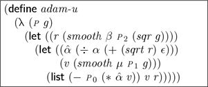

Its parameter has two accompaniments.

<sup>36</sup>

How is it different?

†This algorithm, known as *Adam*, improves gradient descent for stochastic objective functions. Thanks, Diederik Pieter Kingma (1983–) and Jimmy Lei Ba.

For those who might have encountered this update algorithm elsewhere, we have simplified it by dropping the bias correction for *v* and *r*.

The first difference is that we use smooth for the accumulation. This causes the gradient to be multiplied by (− 1.0 μ). Since *μ* is typically around 0.9, only a small fraction of the gradient *g* is used for the next *θ*. The rest is made up of the historical average of *v*.

So, the historical average of *v* is much smoother than in the version from frame 151:31 in *velocity-u*.

<sup>37</sup>

Oh yes. In *velocity-u* from that frame the gradient *g* is multiplied by the learning rate, and that is added to *v*.

Is there another difference?

Yes, there is.

The second difference is that to find our well-fitted parameter *p*<sub>0</sub>, we don't use *g* directly. Instead we use the historical averages *v*.

Why is that?

<sup>38</sup>

It is another way of using the velocity of prior revisions to inform the velocity of the current revision.

Correct.

We must also remember to define an *adam-i* and an *adam-d*.

Each parameter *p* in *θ* is now accompanied by two additional tensors *v* and *r*, each with the same shape as *p*.

Define *adam-i*.

<sup>39</sup>

Here it is

(**define** *adam-i*

(λ (*p*)

(**let** ((*v* (*zeroes p*)))

(**let** ((*r v*))

(**list** *p v r*)))))

Define *adam-d*.

<sup>40</sup>

The deflate function again extracts the 0th member from the accompanied parameter, *p*, to get the next *p*

(**define** *adam-d*

(λ (*p*)

*p*<sub>0</sub>))

All our deflate functions (except for *naked-d*) so far are the same. Why don't we use the same name for all of them?

A great question.

We could. We're setting up a pattern that leaves room for representations other than *lists* for accompanied parameters.

<sup>41</sup>

Good idea.

And now define *adam-gradient-descent*.

<sup>42</sup>

Here it is

(**define** *adam-gradient-descent* •

(*gradient-descent*

*adam-i adam-d adam-u*))

Excellent!

The name of this algorithm, Adam, is short for *adaptive moment estimation*. It is *adaptive* because it uses an adaptive learning rate.†

†The accompaniment *v* is known as the gradient's 1st moment and *r* is its 2nd moment.

<sup>43</sup>

How about an example of how to invoke

*adam-gradient-descent*

Here we learn the same result once again using *try-plane* from frame 152:32 but with fewer revisions

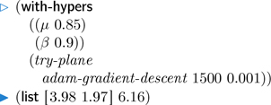

<sup>44</sup>

So now we need only 1500 revisions to get the well-fitted *θ*. This is far fewer than the 15000 that we started with in the original from frame 129:42.

How did we decide the appropriate scalars for *μ* and *β*?

These scalars have been experimentally determined by trying out different combinations to get a lower *revs*.

<sup>45</sup>

Okay.

We now have different kinds of gradient-descent toys that we can use to learn *θ* for various kinds of target functions.

<sup>46</sup>

So what is next?

## The Law of Gradient Descent

The *θ* for a target function is learned by using one of the gradient descent functions.

| Now we move on to understanding how extended functions work. But before that, let's take a smoothie break! | <sup>47</sup> | Yes, a break is much appreciated. |
| --- | --- | --- |

## Faster Toys

*β* 167

*rms-gradient-descent* 169

*adam-gradient-descent* 173

**How about a chocolate**

**and almond butter smoothie?**

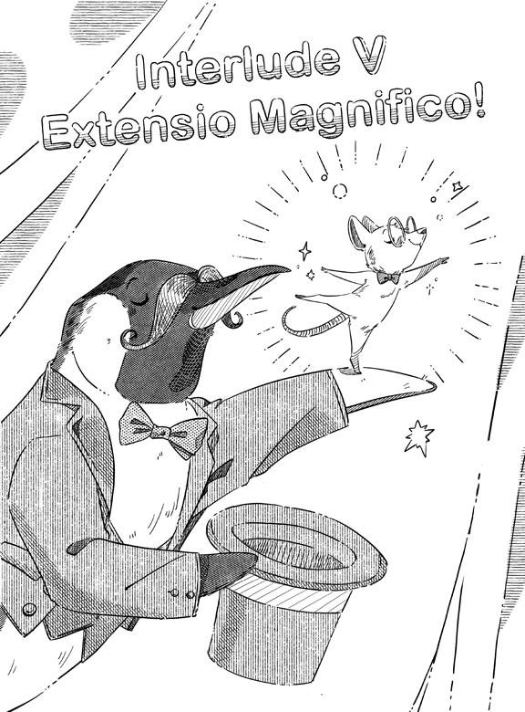

How was the smoothie?

<sup>1</sup>

It was real smooth.

We've been assuming that function extension just works for functions like + and *.

Unlike *The Berglas Effect,*† we reveal our function-extension trick.

†Thanks, David Berglas (1926–).

<sup>2</sup>

Oh, so this interlude is an *extension* of Interlude I?

It is!

We start with a frequently used function on tensors.

This function invokes a given function argument on *each* element of a tensor.

For example, we might want to *add1* to every element of

[3 5 4]

to get

[4 6 5]

<sup>3</sup>

This seems similar to *map* from frame 81:25.

Yes, the two functions are similar.

The function *tmap* takes a function *f* and a tensor *t* as arguments, and invokes *f* on every element of *t* and assembles the results into a tensor as in this same-as chart

1. 1. (*tmap add1* [3 5 4])
2. 2. [(*add1* 3) (*add1* 5) (*add1* 4)]
3. 3. [4 6 5]

<sup>4</sup>

It looks as if the *add1* replicated itself and sneaked into the tensor!

This is similar to descending into a tensor from frame 51:19.

It is!

Descending into a tensor is another way of looking at *tmap*. It descends into a tensor to invoke its function argument on each element it finds.

<sup>5</sup>

But what if we have more than one tensor and we want to invoke a function on elements from each of the tensors?

The function *tmap* is designed to work with multiple tensors, provided the tensors are all of equal length.

For example, here we use two tensors

1. 1. (*tmap* + [3 4 6 1] [1 3 5 5])
2. 2. [(+ 3 1) (+ 4 3) (+ 6 5) (+ 1 5)]
3. 3. [4 7 11 6]

<sup>6</sup>

Okay.

Now let us see how we can use *tmap* for extending functions.

We start with the extended function *sqrt*. Assume that *sqrt*<sup>0</sup> is the (unextended) primitive function that finds the positive square root of a scalar.

When *t* is a scalar, we find the square root using *sqrt*<sup>0</sup>.

What should *A* be?

<sup>7</sup>

For the extension behavior, A must descend into the tensor until it finds a scalar and invokes *sqrt*<sup>0</sup> on it.

Excellent.

What function do we know that allows us to descend into tensors?

<sup>8</sup>

It is *tmap*!

Correct.

Now to find *S*. This function is invoked on each element of *t*, and it should produce its square root. If each element of *t* is a scalar, it should invoke *sqrt*<sup>0</sup> on it, but if each element is a tensor of rank 1 or higher, it must descend into it.

<sup>9</sup>

That sounds familiar.

This must mean that *S* is

*sqrt*

Perfect.

In the definition in frame 7, our base test uses *scalar?*. Let's replace it with a different function

*of-rank?*

which accepts a rank and a tensor and checks if that tensor has the given rank.

Here, we'll check for 0

(**define** *sqrt*

(λ (*t*)

(**cond**

((*of-rank?* 0 *t*) (*sqrt*<sup>0</sup> *t*))

(**else** (*tmap sqrt t*)))))

<sup>10</sup>

This is it, right?

(**define** *of-rank?*

(λ (*n t*)

(= (*rank t*) *n*)))

That definition is correct, but here's a more fun one. Let's start with its skeleton

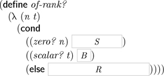

Find *S*, *B*, and *R*.

<sup>11</sup>

Let's begin with *S*, which is true only if *S* is (*scalar? t*). So, *S* is

(*scalar? t*)

For *B*, since the first **cond**-clause test failed, we know that *n* is greater than 0, so if *t* is a scalar, then *B* is

#f

Finally, for *R*, *t* has the rank *n* only if *t|*<sub>0</sub> has the rank *n* − 1. We can verify this recursively. So, *R* is

(*of-rank?* (*sub1 n*) *t|*<sub>0</sub>)

changing both *n* and *t* to eventually pass either the first or second base test.

Excellent.

Here is the final *of-rank?*

(**define** *of-rank?*

(λ (*n t*)

(**cond**

((*zero? n*) (*scalar? t*))

((*scalar? t*) **#**f)

(**else** (*of-rank?* (*sub1 n*) *t*|<sub>0</sub>)))))

Using the same tensor *t* as before in frame 42:44, show a same-as chart for

(*of-rank?* 3 *t*)

<sup>12</sup>

Here it is

1. 1. (*of-rank?* 3 [[[8] [9]] [[4] [7]]])
2. 2. (*of-rank?* 2 [[8] [9]])
3. 3. (*of-rank?* 1 [8])
4. 4. (*of-rank?* 0 8)
5. 5. #t

Great.

What if 3 were replaced by any other natural number?

<sup>13</sup>

Then the result would be

#f

Returning to *sqrt*, why is it dashed in frame 10?

As usual, we're going to reconsider it.

This function is specific to square roots, because we invoke *sqrt*<sup>0</sup> only on scalars. Let's refer to this as the

*base function*

Instead of having a fixed value of the base function of one argument, here *sqrt*<sup>0</sup>, we accept it as an additional argument.

<sup>14</sup>

Does that allow us to extend any base function of one argument?

Yes.

Let's name this generalized function *ext1* because it extends functions of one argument. Here is a skeleton for it

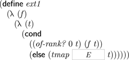

Invoking *ext1* with a base function *f* results in a function that either invokes *f* on *t* if *t*'s rank is 0, or descends into *t* otherwise.

What is *E*?

<sup>15</sup>

*E* must also be the function that invokes the base function *f* on scalars, or descends into tensors of higher rank. This must mean *E* is

(*ext1 f* )

Excellent.

Here is a dashed *ext1*

(**define** *ext1*

(λ (*f* )

(λ (*t*)

(**cond**

((*of-rank?* 0 *t*) (*f t*))

(**else** (*tmap* (*ext1 f* ) *t*))))))

Using *ext1*, define *sqrt*.

<sup>16</sup>

Here it is

(**define** *sqrt*

(*ext1 sqrt*<sup>0</sup>))

How about another example?

A good idea.

How can we define the function *zeroes* from frame 150:27 using *ext1*?

<sup>17</sup>

Oh, we can think of *zeroes* as extending a function that results in 0.0 for every scalar!

Here is how we define *zeroes*

(**define** *zeroes*

(*ext1* (λ (*x*) 0.0)))

Perfect.

<sup>18</sup>

But why are the definitions of *ext1*, *sqrt*, and *zeroes* dashed?

This *ext1* so far works on extending functions that operate only on scalars.

Sometimes, however, we need to extend functions like *sum*<sup>1</sup> in frame 53:24 that only operate on tensors<sup>1</sup>.

<sup>19</sup>

Oh, so instead of checking

(*of-rank?* 0 *t*)

as we see in *ext1*, we'll have to look for a rank of 1 when extending *sum*<sup>1</sup>.

That is correct.

We refer to this as the

*base rank*

<sup>20</sup>

So the base rank for

*sum*<sup>1</sup>

is 1?

Good guess!

What is the base rank for *sqrt*<sup>0</sup>?

<sup>21</sup>

It is 0.

Right.

So when extending a function *f* , we must also accept its base rank *n* as an argument.

Here's a skeleton of our updated *ext1*

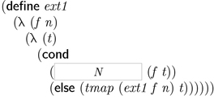

Find *N*.

<sup>22</sup>

Here we must check for a rank of *n*. So, *N* is

(*of-rank? n t*)

Correct.

Here, then, is the final *ext1*

(**define** *ext1* *•*

(λ (*f n*)

(λ (*t*)

(**cond**

((*of-rank? n t*) (*f t*))

(**else** (*tmap* (*ext1 f n*) *t*))))))

How about *sqrt* and *zeroes* using this function?

<sup>23</sup>

We must now also provide the base rank for *sqrt*<sup>0</sup> when we invoke *ext1*.

Here *sqrt*'s base rank is 0

(**define** *sqrt* •

(*ext1 sqrt*<sup>0</sup> 0))

Similarly, for *zeroes*, the base function also has the base rank 0

(**define** *zeroes* •

(*ext1* (λ (*x*) 0.0) 0))

Perfect.

Now define *sum*, which extends *sum*<sup>1</sup>.

<sup>24</sup>

We invoke *ext1* with a base rank of 1

(**define** *sum* •

(*ext1 sum*<sup>1</sup> 1))

Can we see an example where the base rank is 2?

Sure.

Consider the function *flatten*<sup>2</sup> that flattens a tensor<sup>2</sup> into a tensor<sup>1</sup>. It does this by concatenating together each of the nested tensors<sup>1</sup>.

<sup>25</sup>

Example, please?

With the notation from pages 113–114

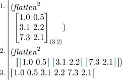

<sup>26</sup>

Is this a function we are going to extend?

We are!

(**define** *flatten* •

(*ext1 flatten*<sup>2</sup> 2))

<sup>27</sup>

Could we see how it works?

Sure.